# Range Characterization and Diet of the Chisana Caribou Herd, Alaska

Authors, etc.

## Wrangell-St. Elias National Park and Preserve

# Abstract

# Introduction

The Chisana Caribou Herd (CCH) is a small herd of woodland caribou located in northeastern Wrangell St. Elias (WRST) National Park and Preserve in Alaska and the Tetlin National Wildlife Refuge in the Yukon. During the early 1990s, many caribou herds in interior Alaska experienced population declines of varying severity (Valkenburg et al., 1996). From 1989 to 2001, the CCH population dropped from an estimated 1800 to 400 individuals (R. Farnell, unpublished data). The CCH became listed as a “Specially Protected” population in 2002 under the Yukon’s Federal Species at Risk Act. After the implementation of a captive rearing program and the development of an international, multiagency management plan, the CCH population is now stable and open to subsistence hunting. However, the current population is significantly below pre-decline levels. Several factors most likely contributed to the CCH population decline including predation, low recruitment, and poor habitat.

Lichens may be the greatest feature limiting CCH habitat quality. Lichens comprise up to 60-86% of the winter diets of Yukon woodland caribou herds, while moss makes up only 1-8%, as estimated from the microhistological analysis of fecal pellets (Farnell and Gardner, 2002). Relative to other Alaskan and Yukon caribou, the CCH appear to have a winter diet that is unusually and low in lichen (31%) and high in moss (51%). Overflight landcover assessments and collections from a limited number of plots suggest that lichen cover with the range is sparse and dominated by nutrient-poor Stereocaulon species (Clarke and Waterreus, 2012), an indicator of poor winter habitat for reindeer (Swanson and Barker, 1992). More data on lichen and moss cover with the CCH range are needed to corroborate these results. In addition to cover, lichen biomass is an important measurement of caribou forage quality. If overgrazing occurs, lichen biomass may not be correlated with lichen cover, and caribou have shown preference for regions with low lichen cover, but high lichen biomass (Collins et al., 2010). Lichen biomass is commonly estimated from mean lichen mat thickness (Lieb, 1994; Arseneault et al., 1997; Moen et al. 2007; Collins et al., 2010). Therefore, measuring lichen thickness and cover in the CCH range may capture key details for assessing winter habitat.

Summer forage is also an important component of caribou habitat. Low recruitment in caribou populations in the Southern Alaska Peninsula is thought to be due to a combination of low winter lichen availability and poor summer range quality (Post and Klein, 1999). Caribou summer diet is typically composed of grasses, sedges, forbs, and willows (Boertje, 1984). Manipulation experiments within the CCH range suggest that climate change may affect caribou summer forage quality and abundance (Lenart et al., 2002). In this study, we aim to establish baseline monitoring of vegetation within the CCH range. Secondly, we estimate lichen cover and biomass across the CCH range to assess habitat quality relative to those of other caribou, particularly the neighboring Kluane, Aishihik, and Nelchina herds. In this report, we describe results from first season of data collection, present preliminary findings, and offer recommendations for future study years.

# Methods

## Vegetation Cover

We chose to proportionally allocate sampling sites to six major ecotypes within the study area (Table 1). Major ecotypes were developed by consolidating the detailed ecotypes mapped in WRST by Jorgenson et al. (2008) using satellite imagery. We grouped Jorgenson et al. ecotypes into groups based on the similarity of their definitions and geographic size (Table 1; Fig. 2). We included all ecotypes except for glaciated barrens. In our study region, the three most common ecotypes by percent cover are Alpine Dwarf Shrub/Barrens (28.1%), Subalpine Wood/Shrub (28.1%), and Alpine Sedge-Dwarf Shrub (24.3%). Riverine, Alpine Meadow, and Forest ecotypes make up the remaining 19.4% of the region.

We identified taxa to the species or genus-level. We considered forage lichen as the genera Cladina, Cladonia (excluding species with cup-shaped podetia), Cetraria (excluding C. richardsonii), and Stereocaulon, following Collins et al. (2011). We estimated the percent cover of major life forms across the entire study area as the average of ecotype means weighted by ecotype area.

## Ecotypes

Table 1. Ecotypes of Chisana caribou herd range, ranked by percent cover.

|  | **Major ecotype** | **Included detailed ecotypes*** | **Distinguishing features** | **Landcover** |
| --- | --- | --- | --- | --- |
| 1 | Alpine Dwarf-Shrub/Barrens | Alpine Dryas Dwarf Shrub Alpine Barrens Alpine Ericaeous Dwarf Shrub | *Dryas* spp. and other evergreen dwarf shrubs dominant, trees or tall shrubs absent, and rare graminoids; occurs at high elevations | 28.1% |
| 2 | Subalpine Wood/Shrub | Subalpine Willow-Birch Shrub Subalpine Spruce Woodland | Characterized by tall (> 0.2 m) deciduous shrubs; few sedges and grasses; tree cover < 20% | 28.1% |
| 3 | Alpine Sedge-Dwarf Shrub | Alpine Sedge-Dwarf Willow Meadow | Deciduous shrubs dominant, but with lower frequencies than in ecotype 2; sedges co-dominant; trees absent; relatively high species diversity | 24.3% |
| 4 | Riverine | Riverine Circumalkaline Barrens Riverine Sandy Willow Shrub Riverine Dryas Dwarf Shrub Riverine Tall Alder Shrub Riverine Low Silverberry Shrub | On or near braided streams; deciduous or evergreen dwarf shrubs are dominant and trees uncommon | 7.5% |
| 5 | Alpine Meadow | Alpine Tussock Meadow Alpine Sedge Meadow | Tussocks > 25% and sedge cover approaching 60%; dwarf shrubs can be co-dominant; no trees; wet soil | 7.3% |
| 6 | Forest | Subalpine Poplar Forest Riverine White Spruce Forest Riverine Gravelly Poplar Forest Riverine Spruce-Poplar Forest | Common on or near overbank deposits; characterized by > 20% tree cover and thick mossy floor | 4.6% |

## Lichen Mat Thickness and Biomass

We estimated lichen biomass for each plot from mean lichen height using the Moen et al. (2007) regression based on four forage lichen species:

## Litter

Added up the number of transects by litter type and divided by the total number of transects.

## Number of plots by ecotype

Why only one plot in Forest? Merkhofer: “We found that Forest ecotypes made for difficult helicopter landing access and subsequently sampled only one site from this ecotype. Future sampling should be targeted to these under-sampled ecotypes.”

Table 2. Number of plots by ecotype.

| Ecotype | n |
| --- | --- |
| Alpine Dwarf Shrub/Barrens | 11 |
| Subalpine Wood/Shrub | 9 |
| Alpine Sedge-Dwarf Shrub | 5 |
| Alpine Meadow | 4 |
| Riverine | 3 |
| Forest | 1 |

## Map

A map of the plots is shown below:

[interactive chart not shown]

Figure 2. Map of sampling plots.

# Caribou Ecotype Preference

I performed a spatial join of the GPS collar data over the major ecotypes to see where caribou were spending their time. I used the ‘Join Attributes by Location’ tool in QGIS to add the ecotype to each GPS fix. I then summarized the number of pings by ecotype.

# Results

## Vegetation Cover

### Foliar cover

*Unweighted by ecotype area.

Question: Merkhofer states “We estimated the percent cover of major life forms across the entire study area as the average of ecotype means weighted by ecotype area.” She did not give a formula. I’m uncertain how to weight means. The tables below give gover as the number of point intercept hits divided by the total number of available tries, unweighted by ecotype area.]

Results:

- Overall foliar plant cover in the vegetation plots we sampled was dominated by dwarf birch, sedges, *Dryas* and willow, species emblematic of alpine tundra.

Table 3. Percent foliar cover by taxa in the range of the Chisana caribou herd having cover greater than 1%.

| Taxa | % cover |
| --- | --- |
| Betula glandulosa | 16.540404 |
| Unknown sedge | 12.196970 |
| Dryas octopetala | 9.318182 |
| Salix sp. | 7.777778 |
| Unknown graminoid | 2.550505 |
| Cassiope tetragona | 2.398990 |
| Festuca altaica | 2.398990 |
| Salix reticulata | 2.272727 |
| Picea glauca | 2.121212 |
| Empetrum nigrum | 1.994949 |
| Ledum palustre | 1.969697 |
| Salix arctica | 1.717172 |
| Unknown grass | 1.717172 |
| Unknown rush | 1.464646 |
| Vaccinium uliginosum | 1.439394 |
| Carex aquatilis | 1.313131 |
| Carex bigelowii | 1.262626 |
| Dryas integrifolia | 1.186869 |
| Poa arctica | 1.161616 |
| Equisetum scirpoides | 1.085859 |

### Basal Cover

*Unweighted by ecotype area.

Table 4. Percent basal cover by taxa in the range of the Chisana caribou herd having cover greater than 0.1%.

| Taxa | % cover |
| --- | --- |
| Moss | 42.5757576 |
| Unknown sedge | 6.1616162 |
| Cladonia sp. | 4.6464646 |
| Stereocaulon sp. | 3.5606061 |
| Cetraria sp. | 3.2575758 |
| Empetrum nigrum | 3.1565657 |
| Peltigera sp. | 2.3989899 |
| Dryas octopetala | 1.1868687 |
| Unknown rush | 0.9090909 |
| Thamnolia sp. | 0.7575758 |
| Dryas integrifolia | 0.6565657 |
| Arctostaphylos uva-ursi | 0.6313131 |
| Unknown grass | 0.3787879 |
| Vaccinium vitis-idaea | 0.3787879 |
| Festuca altaica | 0.2777778 |
| Masonhalea richardsonii | 0.2525253 |
| Poa arctica | 0.2525253 |
| Salix sp. | 0.2272727 |
| Alectoria ochroleuca | 0.2020202 |
| Dactylina arctica | 0.1767677 |
| Betula glandulosa | 0.1262626 |
| Peltigera canina | 0.1262626 |
| Unknown graminoid | 0.1262626 |
| Picea glauca | 0.1010101 |
| Salix reticulata | 0.1010101 |

## Lichen Layer Thickness and Biomass

NOTES on lichen biomass: I’m using LM’s conversion of lichen height to biomas “We estimated lichen biomass for each plot from mean lichen height using the Moen et al. (2007) regression based on four forage lichen species as B=1135.6T where T is mean lichen mat thickness (cm) and B is mean lichen mat biomass (kg/ha). ,1135.6 * AVG(IFNULL(v.LichenHeight,0)) as [Estimated lichen biomass (kg/ha)” without really knowing much about that methodology.

Also Moen et al. considered 4 leafy lichens. LM and JP did not distinguish any species of lichens in their lichen height measument at each point intercept (“We calculated the mean lichen height of each plot as the average of all heights, including zero heights where no lichen was present”).

```
## # A tibble: 6 × 6
##   Ecotype                    Plots Transects Mean lichen thicknes…¹     SD     n
##   <chr>                      <int>     <int>                  <dbl>  <dbl> <int>
## 1 Alpine Dwarf Shrub/Barrens    10        30                  1.28   0.347   219
## 2 Alpine Meadow                  4        12                  1.47   0.362   163
## 3 Alpine Sedge-Dwarf Shrub       5        14                  1.70   0.549    69
## 4 Forest                         1         3                  2.77  NA        23
## 5 Riverine                       3         9                  0.829  0.371    61
## 6 Subalpine Wood/Shrub           8        19                  1.20   0.781    87
## # ℹ abbreviated name: ¹`Mean lichen thickness (cm)`
```

Table 5. Mean lichen thickness (cm) by ecotype. Note that only one plot was sampled in the Forest ecotype..

| Ecotype | Plots | Transects | Mean lichen thickness (cm) | SD | n |
| --- | --- | --- | --- | --- | --- |
| Alpine Dwarf Shrub/Barrens | 10 | 30 | 1.28 | 0.35 | 219 |
| Alpine Meadow | 4 | 12 | 1.47 | 0.36 | 163 |
| Alpine Sedge-Dwarf Shrub | 5 | 14 | 1.70 | 0.55 | 69 |
| Forest | 1 | 3 | 2.77 |  | 23 |
| Riverine | 3 | 9 | 0.83 | 0.37 | 61 |
| Subalpine Wood/Shrub | 8 | 19 | 1.20 | 0.78 | 87 |

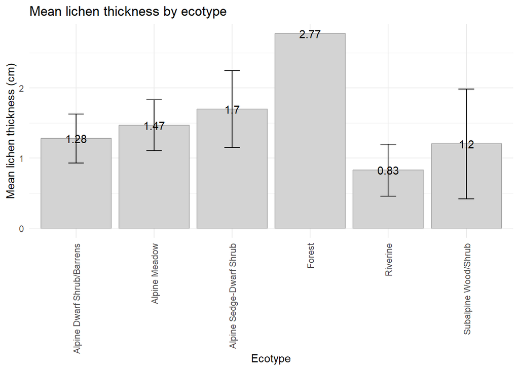

Figure 3. Mean lichen thickness (cm) by ecotype. Error bars represent one standard deviation. Note that only one plot was sampled in the Forest ecotype.

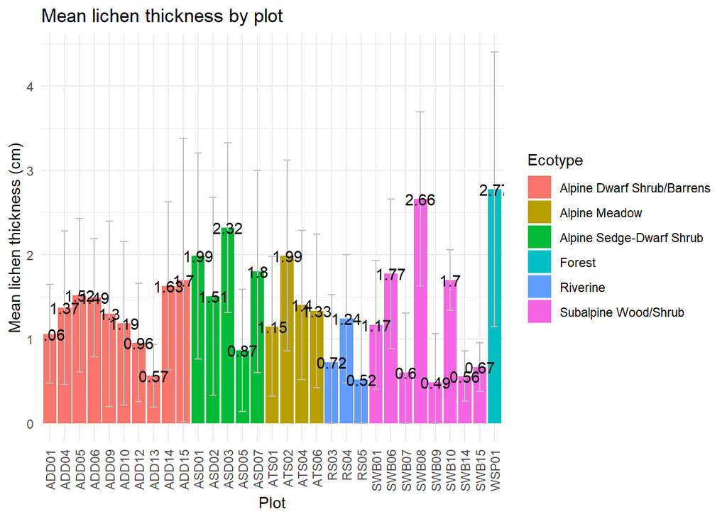

Figure 4. Mean lichen thickness (cm) by plot Error bars represent one standard deviation. Note that only one plot was sampled in the Forest ecotype.

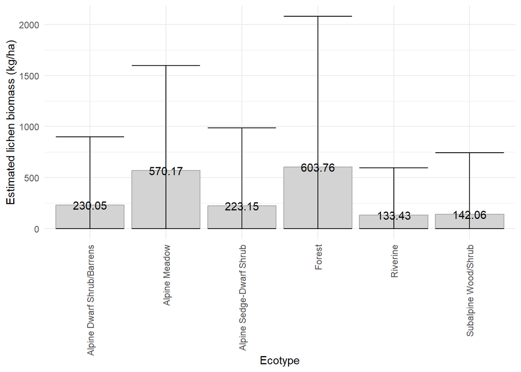

## Litter

Table 7. Litter dominance (count of transects by litter type divided by total number of transects.

| Litter type | Number of transects | % of transects |
| --- | --- | --- |
| Moss | 43 | 43.4 |
|  | 12 | 12.1 |
| Soil | 12 | 12.1 |
| Herbaceous | 8 | 8.1 |
| Embedded litter | 5 | 5.1 |
| Dryas octopetala | 4 | 4.0 |
| Moss/lichen | 4 | 4.0 |
| Coniferous | 3 | 3.0 |
| Graminoid | 2 | 2.0 |
| Carex/forb | 1 | 1.0 |
| Lichen | 1 | 1.0 |
| Lichen/Moss | 1 | 1.0 |
| Moss/Sedge | 1 | 1.0 |
| Sedge | 1 | 1.0 |
| Shrub litter | 1 | 1.0 |

## Caribou Ecotype Preference

### Ecotype preference

Table 8. Ecotype preference of Chisana caribou as determined from the number of GPS collar fixes by ecotype.

| Ecotype | Percent of GPS fixes |
| --- | --- |
| Subalpine Wood/Shrub | 30% |
| Alpine Sedge-Dwarf Shrub | 29% |
| Alpine Dwarf Shrub/Barrens | 20% |
| Alpine Meadow | 16% |
| Riverine | 1% |
| Forest | 1% |

Total GPS fixes = 13929

### Ecotype Preference By Month

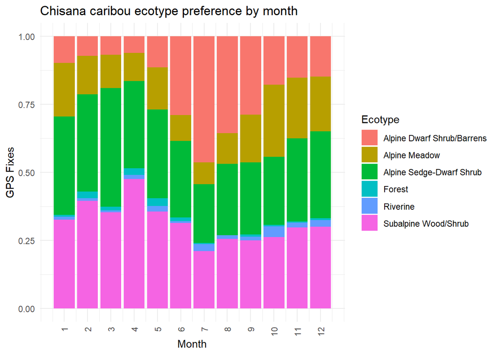

Figure 4. Chisana caribou ecotype preference by month as determined from GPS collar data.

## Fecal Pellet Analysis

| Plant | Mean | n |
| --- | --- | --- |
| Classic Moss | 27.4058824 | 34 |
| Cladonia/Cladina lichens | 26.6558824 | 34 |
| Cetraria/Dactylina lichens | 7.5911765 | 34 |
| Alectoria/Bryoria lichen | 7.5352941 | 34 |
| Foliose lichen | 4.9558824 | 34 |
| Carex spp. | 4.1411765 | 34 |
| Equisetum spp. | 4.0676471 | 34 |
| Aulacomnium Moss | 2.8242424 | 33 |
| Dryas spp. leaf | 2.2615385 | 26 |
| Poa arctica | 1.7166667 | 30 |
| Empetrum nigrum leaf | 1.4925926 | 27 |
| Betula spp. stem | 1.3000000 | 19 |
| Sphagnum sp. Moss | 1.2866667 | 30 |
| Polytrichum juniperinum | 1.1727273 | 22 |
| Salix spp. leaf | 1.0714286 | 21 |
| Anthoxanthum monticola | 0.9035714 | 28 |
| Rubus spp. stem | 0.7833333 | 6 |
| Stereocaulon sp. lichen | 0.7575758 | 33 |
| Populus balsamifera stem | 0.7500000 | 8 |
| Alnus viridis stem | 0.7500000 | 2 |
| Salix spp. stem | 0.7312500 | 16 |
| Vaccinium spp. leaf | 0.7200000 | 5 |
| Arctagrostis latifolia | 0.7115385 | 26 |
| Oxytropis spp. | 0.7111111 | 9 |
| Calamagrostis canadensis | 0.7052632 | 19 |
| Ledum spp.stem | 0.7000000 | 6 |
| Empetrum nigrum stem | 0.7000000 | 11 |
| Betula spp. leaf | 0.7000000 | 1 |
| Festuca altaica | 0.6714286 | 7 |
| Dasiphora (Potentilla) fruticosa | 0.6250000 | 8 |
| Vaccinium spp. stem | 0.6142857 | 7 |
| Cassiope tetragona stem | 0.6000000 | 1 |
| Unknown Shrub stems | 0.5812500 | 16 |
| Lupinus arcticus | 0.5333333 | 18 |
| Unknown Shrub leaves | 0.5117647 | 17 |
| Eriophorum spp. | 0.5111111 | 9 |
| Rosa acicularis stem | 0.5000000 | 1 |
| Rhus spp. stem | 0.5000000 | 1 |
| Populus balsamifera leaf | 0.5000000 | 9 |
| Luzula spp. | 0.5000000 | 1 |
| Linnaea borealis leaf | 0.5000000 | 1 |
| Dryas spp. stem | 0.5000000 | 20 |
| Cassiope tetragona leaf | 0.4800000 | 5 |
| Juncus castaneus | 0.4687500 | 16 |
| Minuartia obtusiloba | 0.4571429 | 14 |
| Unknown Grasses | 0.4375000 | 8 |
| Arctostaphylos uva-ursi stem | 0.4333333 | 3 |
| Ledum spp. leaf | 0.4230769 | 26 |
| Stellaria longipes | 0.4000000 | 4 |
| Lycopodium annotinum | 0.4000000 | 2 |
| Kobresia simpliciuscula | 0.4000000 | 1 |
| Astragalus sp. | 0.3800000 | 10 |
| Oxycoccus macrocarpus | 0.3600000 | 5 |
| Unknown Forbs | 0.3533333 | 15 |
| Nephroma arcticum lichen | 0.3375000 | 16 |
| Polygonum spp. | 0.3000000 | 2 |
| Solidago multiradiata | 0.2666667 | 3 |

# Discussion

# Appendix A: Sampling Plots

## List Of Plots

Table ?. Sampling plots.

| Plot | Ecotype | EstablishDate | Elevation (m) | Latitude | Longitude |
| --- | --- | --- | --- | --- | --- |
| ADD01 | Alpine Dwarf Shrub/Barrens | 2016-07-17 | 1420.039 | 62.08734 | -141.8660 |
| ADD04 | Alpine Dwarf Shrub/Barrens | 2016-07-16 | 1755.171 | 61.93552 | -141.9120 |
| ADD05 | Alpine Dwarf Shrub/Barrens | 2016-07-17 | 1778.203 | 62.02330 | -141.4990 |
| ADD06 | Alpine Dwarf Shrub/Barrens | 2016-07-15 | 1634.397 | 61.93408 | -141.1590 |
| ADD07 | Alpine Dwarf Shrub/Barrens | 2015-07-27 | 1430.455 | 61.96506 | -141.7315 |
| ADD09 | Alpine Dwarf Shrub/Barrens | 2015-07-11 | 1553.244 | 62.25612 | -142.4690 |
| ADD10 | Alpine Dwarf Shrub/Barrens | 2015-07-27 | 1571.130 | 61.97373 | -141.5712 |
| ADD12 | Alpine Dwarf Shrub/Barrens | 2016-07-16 | 1791.005 | 61.89077 | -141.8270 |
| ADD13 | Alpine Dwarf Shrub/Barrens | 2015-07-27 | 1930.868 | 62.06235 | -142.1865 |
| ADD14 | Alpine Dwarf Shrub/Barrens | 2015-07-27 | 1285.111 | 61.97960 | -141.4711 |
| ADD15 | Alpine Dwarf Shrub/Barrens | 2016-07-15 | 1971.142 | 61.93471 | -141.5820 |
| ASD01 | Alpine Sedge-Dwarf Shrub | 2015-07-27 | 1352.073 | 61.89981 | -141.1643 |
| ASD02 | Alpine Sedge-Dwarf Shrub | 2015-07-12 | 1327.991 | 61.75152 | -141.3301 |
| ASD03 | Alpine Sedge-Dwarf Shrub | 2016-07-15 | 1312.164 | 61.75139 | -141.0540 |
| ASD05 | Alpine Sedge-Dwarf Shrub | 2015-07-26 | 1356.013 | 61.95466 | -142.0188 |
| ASD07 | Alpine Sedge-Dwarf Shrub | 2015-07-21 | 1314.135 | 61.81529 | -141.6402 |
| ATS01 | Alpine Meadow | 2015-07-13 | 1634.906 | 61.89196 | -141.5397 |
| ATS02 | Alpine Meadow | 2015-07-28 | 1195.729 | 62.00252 | -141.2674 |
| ATS04 | Alpine Meadow | 2015-07-12 | 1620.190 | 61.84752 | -141.4842 |
| ATS06 | Alpine Meadow | 2015-07-29 | 1477.492 | 62.05676 | -141.7929 |
| RS03 | Riverine | 2015-07-11 | 1194.302 | 62.13432 | -142.3045 |
| RS04 | Riverine | 2015-07-29 | 1332.846 | 62.09194 | -141.8064 |
| RS05 | Riverine | 2015-07-11 | 1073.724 | 62.14444 | -142.1755 |
| SWB01 | Subalpine Wood/Shrub | 2015-07-28 | 1316.677 | 62.00130 | -141.1361 |
| SWB06 | Subalpine Wood/Shrub | 2016-07-16 | 1560.109 | 62.09998 | -142.0030 |
| SWB07 | Subalpine Wood/Shrub | 2015-07-21 | 1478.406 | 61.89189 | -141.4501 |
| SWB08 | Subalpine Wood/Shrub | 2016-07-17 | 1307.897 | 62.01961 | -141.3340 |
| SWB09 | Subalpine Wood/Shrub | 2015-07-11 | 1182.380 | 62.18664 | -142.3202 |
| SWB10 | Subalpine Wood/Shrub | 2015-07-12 | 1209.707 | 61.79014 | -141.4875 |
| SWB12 | Subalpine Wood/Shrub | 2015-07-26 | 1403.939 | 61.96335 | -141.9544 |
| SWB14 | Subalpine Wood/Shrub | 2015-07-13 | 1232.468 | 62.15854 | -142.2435 |
| SWB15 | Subalpine Wood/Shrub | 2016-07-16 | 1508.760 | 62.00719 | -141.7080 |
| WSP01 | Forest | 2015-07-28 | 1011.836 | 61.92991 | -141.0560 |

## Elevational Profiles

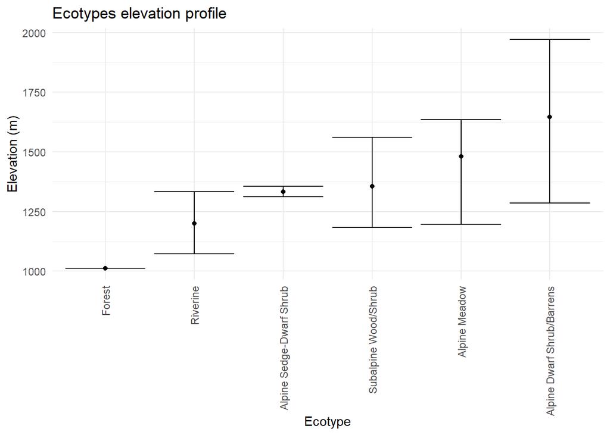

Table 12. Sampling plots elevation profile by ecotype. Error bars represent the minimum and maximum plot elevation for each ecotype.

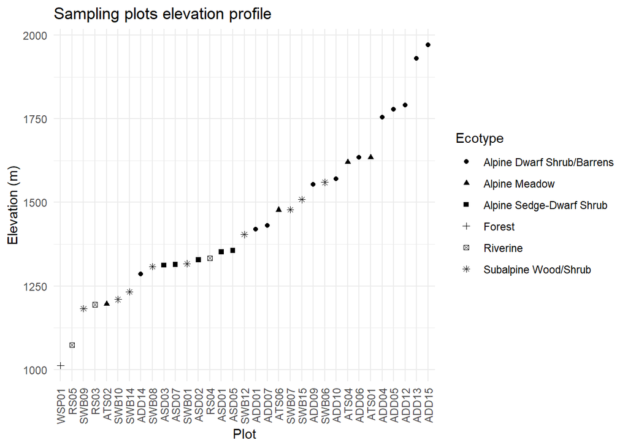

Figure 4. Sampling plots elevation profile by plot.

# Appendix B: Vegetation Summary By Ecotype

# Alpine Dwarf Shrub/Barrens

## Sampling Plots.

Table 12 . Plots And sampling dates in the Alpine Dwarf Shrub/Barrens ecotype.

| Plot | Elevation (m) | Sampling Date |
| --- | --- | --- |
| ADD01 | 1420.0 | 2016-07-17 |
| ADD04 | 1755.2 | 2016-07-16 |
| ADD05 | 1778.2 | 2016-07-17 |
| ADD06 | 1634.4 | 2016-07-15 |
| ADD07 | 1430.5 | 2015-07-27 |
| ADD09 | 1553.2 | 2015-07-11 |
| ADD10 | 1571.1 | 2015-07-27 |
| ADD12 | 1791.0 | 2016-07-16 |
| ADD13 | 1930.9 | 2015-07-27 |
| ADD14 | 1285.1 | 2015-07-27 |
| ADD15 | 1971.1 | 2016-07-15 |

Mean elevation (m) = 1647.3 , number of plots = 11

## Foliar Cover

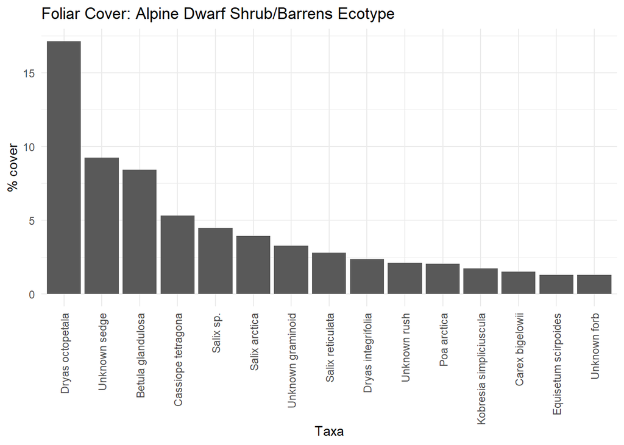

Figure 4 . Foliar percent cover in the Alpine Dwarf Shrub/Barrens ecotype having percent cover greater than 1%. X-axis taxa may include abiotic strata such as soil, litter or rock where no plant species were intercepted.

Table 13 . Foliar cover in the Alpine Dwarf Shrub/Barrens ecotype.

| ScientificName | Hits | Opportunities | % cover |
| --- | --- | --- | --- |
| Dryas octopetala | 226 | 1320 | 17.1212121212121 |
| Unknown sedge | 122 | 1320 | 9.24242424242424 |
| Betula glandulosa | 111 | 1320 | 8.40909090909091 |
| Cassiope tetragona | 70 | 1320 | 5.3030303030303 |
| Salix sp. | 59 | 1320 | 4.46969696969697 |
| Salix arctica | 52 | 1320 | 3.93939393939394 |
| Unknown graminoid | 43 | 1320 | 3.25757575757576 |
| Salix reticulata | 37 | 1320 | 2.8030303030303 |
| Dryas integrifolia | 31 | 1320 | 2.34848484848485 |
| Unknown rush | 28 | 1320 | 2.12121212121212 |
| Poa arctica | 27 | 1320 | 2.04545454545455 |
| Kobresia simpliciuscula | 23 | 1320 | 1.74242424242424 |
| Carex bigelowii | 20 | 1320 | 1.51515151515152 |
| Equisetum scirpoides | 17 | 1320 | 1.28787878787879 |
| Unknown forb | 17 | 1320 | 1.28787878787879 |
| TOTAL | 883 |  | 66.8939393939394 |

## Mid-Story Cover

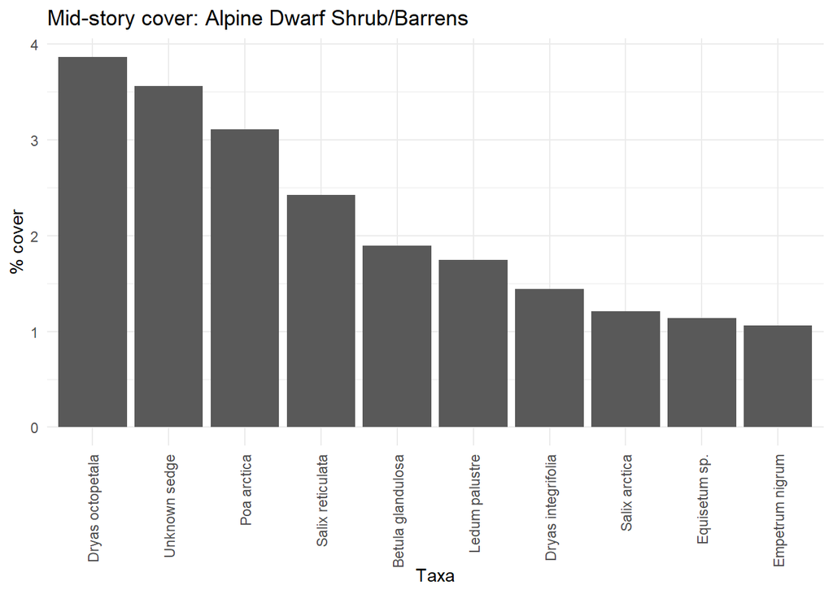

Figure 5 . Mid-story percent cover in the Alpine Dwarf Shrub/Barrens ecotype having percent cover greater than 1%. X-axis taxa may include abiotic strata such as soil, litter or rock where no plant species were intercepted.

Table 14 . Midstory cover in the Alpine Dwarf Shrub/Barrens ecotype.

| ScientificName | Hits | Opportunities | % cover |
| --- | --- | --- | --- |
| Dryas octopetala | 51 | 1320 | 3.86363636363636 |
| Unknown sedge | 47 | 1320 | 3.56060606060606 |
| Poa arctica | 41 | 1320 | 3.10606060606061 |
| Salix reticulata | 32 | 1320 | 2.42424242424242 |
| Betula glandulosa | 25 | 1320 | 1.89393939393939 |
| Ledum palustre | 23 | 1320 | 1.74242424242424 |
| Dryas integrifolia | 19 | 1320 | 1.43939393939394 |
| Salix arctica | 16 | 1320 | 1.21212121212121 |
| Equisetum sp. | 15 | 1320 | 1.13636363636364 |
| Empetrum nigrum | 14 | 1320 | 1.06060606060606 |
| TOTAL | 283 |  | 21.4393939393939 |

## Soil Surface Cover

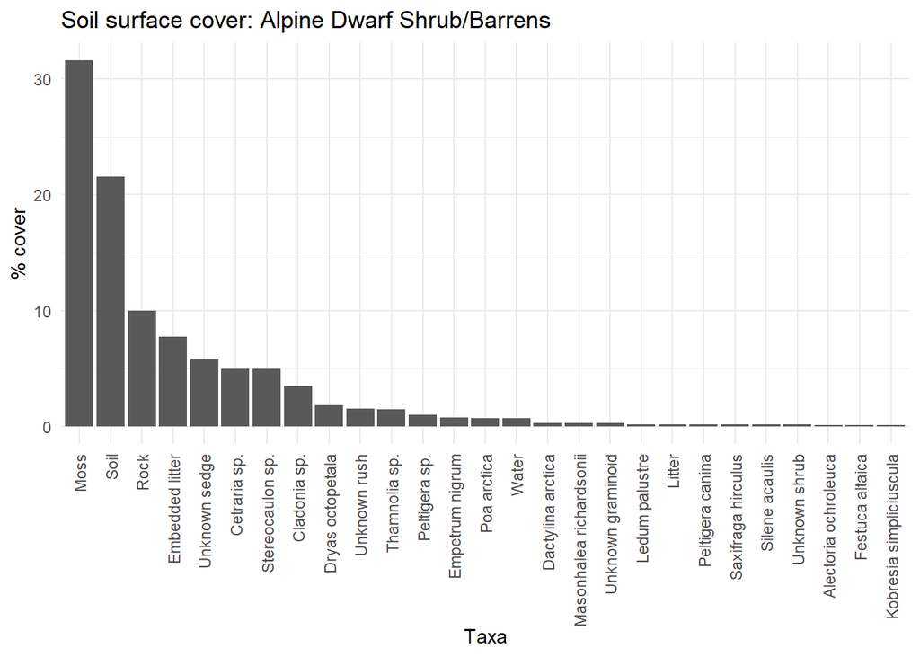

Table 15 . Soil surface cover in the Alpine Dwarf Shrub/Barrens ecotype.

| ScientificName | Hits | Opportunities | % cover |
| --- | --- | --- | --- |
| Moss | 417 | 1320 | 31.5909090909091 |
| Soil | 285 | 1320 | 21.5909090909091 |
| Rock | 132 | 1320 | 10 |
| Embedded litter | 102 | 1320 | 7.72727272727273 |
| Unknown sedge | 77 | 1320 | 5.83333333333333 |
| Cetraria sp. | 65 | 1320 | 4.92424242424242 |
| Stereocaulon sp. | 65 | 1320 | 4.92424242424242 |
| Cladonia sp. | 46 | 1320 | 3.48484848484849 |
| Dryas octopetala | 24 | 1320 | 1.81818181818182 |
| Unknown rush | 20 | 1320 | 1.51515151515152 |
| Thamnolia sp. | 19 | 1320 | 1.43939393939394 |
| Peltigera sp. | 13 | 1320 | 0.984848484848485 |
| Empetrum nigrum | 10 | 1320 | 0.757575757575758 |
| Poa arctica | 9 | 1320 | 0.681818181818182 |
| Water | 9 | 1320 | 0.681818181818182 |
| Dactylina arctica | 4 | 1320 | 0.303030303030303 |
| Masonhalea richardsonii | 4 | 1320 | 0.303030303030303 |
| Unknown graminoid | 4 | 1320 | 0.303030303030303 |
| Ledum palustre | 2 | 1320 | 0.151515151515152 |
| Litter | 2 | 1320 | 0.151515151515152 |
| Peltigera canina | 2 | 1320 | 0.151515151515152 |
| Saxifraga hirculus | 2 | 1320 | 0.151515151515152 |
| Silene acaulis | 2 | 1320 | 0.151515151515152 |
| Unknown shrub | 2 | 1320 | 0.151515151515152 |
| Alectoria ochroleuca | 1 | 1320 | 0.0757575757575758 |
| Festuca altaica | 1 | 1320 | 0.0757575757575758 |
| Kobresia simpliciuscula | 1 | 1320 | 0.0757575757575758 |
| TOTAL | 1320 |  | 100 |

# Alpine Meadow

## Sampling Plots.

Table 12 . Plots And sampling dates in the Alpine Meadow ecotype.

| Plot | Elevation (m) | Sampling Date |
| --- | --- | --- |
| ATS01 | 1634.9 | 2015-07-13 |
| ATS02 | 1195.7 | 2015-07-28 |
| ATS04 | 1620.2 | 2015-07-12 |
| ATS06 | 1477.5 | 2015-07-29 |

Mean elevation (m) = 1482.1 , number of plots = 4

## Foliar Cover

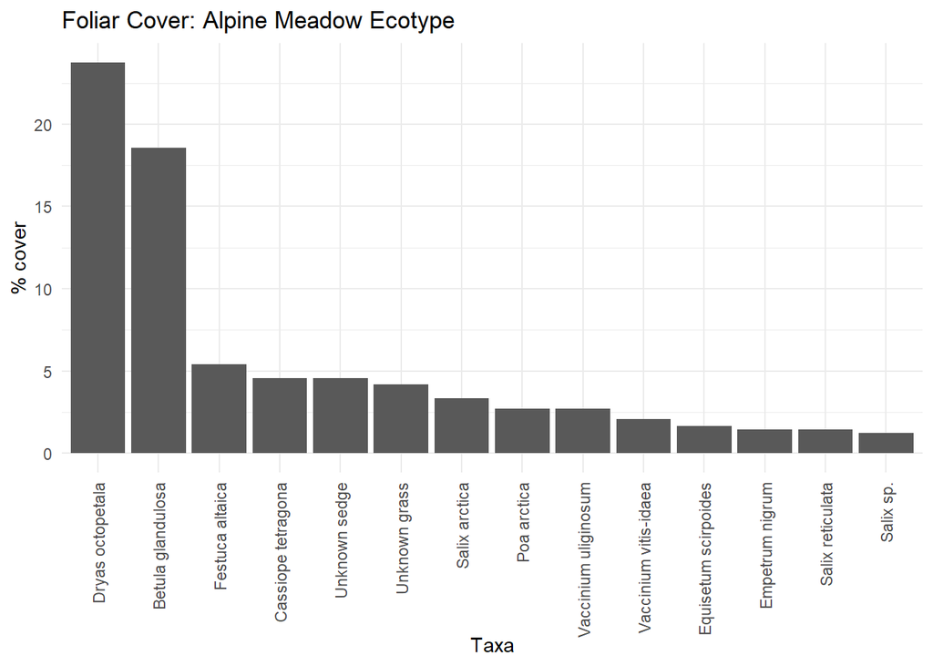

Figure 4 . Foliar percent cover in the Alpine Meadow ecotype having percent cover greater than 1%. X-axis taxa may include abiotic strata such as soil, litter or rock where no plant species were intercepted.

Table 13 . Foliar cover in the Alpine Meadow ecotype.

| ScientificName | Hits | Opportunities | % cover |
| --- | --- | --- | --- |
| Dryas octopetala | 114 | 480 | 23.75 |
| Betula glandulosa | 89 | 480 | 18.5416666666667 |
| Festuca altaica | 26 | 480 | 5.41666666666667 |
| Cassiope tetragona | 22 | 480 | 4.58333333333333 |
| Unknown sedge | 22 | 480 | 4.58333333333333 |
| Unknown grass | 20 | 480 | 4.16666666666667 |
| Salix arctica | 16 | 480 | 3.33333333333333 |
| Poa arctica | 13 | 480 | 2.70833333333333 |
| Vaccinium uliginosum | 13 | 480 | 2.70833333333333 |
| Vaccinium vitis-idaea | 10 | 480 | 2.08333333333333 |
| Equisetum scirpoides | 8 | 480 | 1.66666666666667 |
| Empetrum nigrum | 7 | 480 | 1.45833333333333 |
| Salix reticulata | 7 | 480 | 1.45833333333333 |
| Salix sp. | 6 | 480 | 1.25 |
| TOTAL | 373 |  | 77.7083333333333 |

## Mid-Story Cover

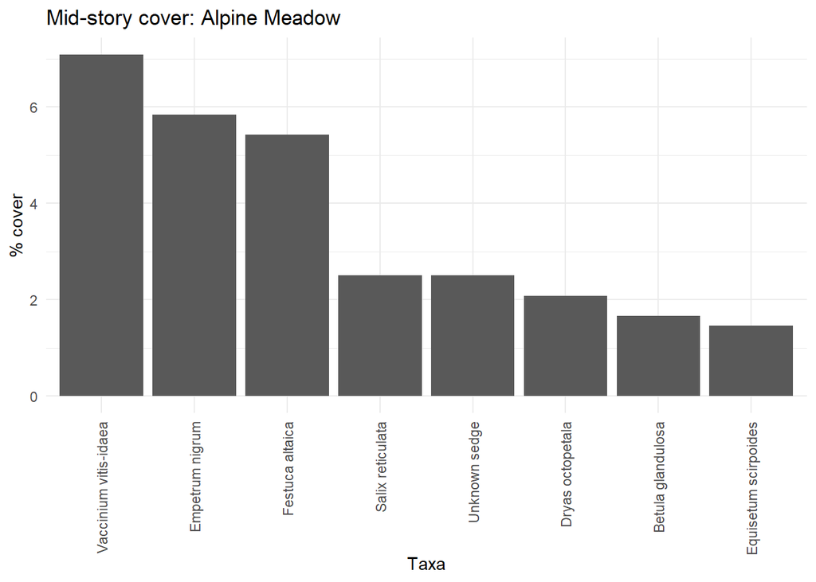

Figure 5 . Mid-story percent cover in the Alpine Meadow ecotype having percent cover greater than 1%. X-axis taxa may include abiotic strata such as soil, litter or rock where no plant species were intercepted.

Table 14 . Midstory cover in the Alpine Meadow ecotype.

| ScientificName | Hits | Opportunities | % cover |
| --- | --- | --- | --- |
| Vaccinium vitis-idaea | 34 | 480 | 7.08333333333333 |
| Empetrum nigrum | 28 | 480 | 5.83333333333333 |
| Festuca altaica | 26 | 480 | 5.41666666666667 |
| Salix reticulata | 12 | 480 | 2.5 |
| Unknown sedge | 12 | 480 | 2.5 |
| Dryas octopetala | 10 | 480 | 2.08333333333333 |
| Betula glandulosa | 8 | 480 | 1.66666666666667 |
| Equisetum scirpoides | 7 | 480 | 1.45833333333333 |
| TOTAL | 137 |  | 28.5416666666667 |

## Soil Surface Cover

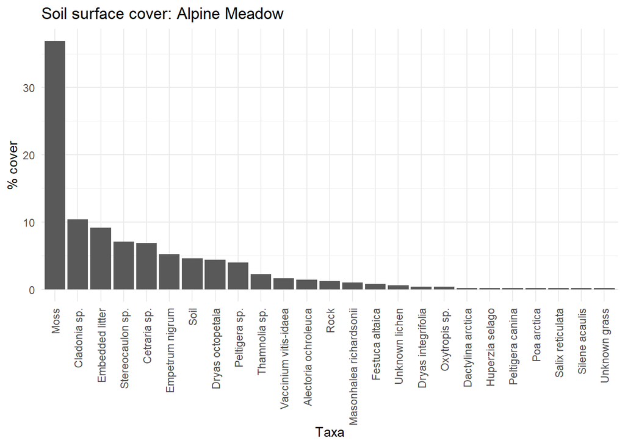

Table 15 . Soil surface cover in the Alpine Meadow ecotype.

| ScientificName | Hits | Opportunities | % cover |
| --- | --- | --- | --- |
| Moss | 177 | 480 | 36.875 |
| Cladonia sp. | 50 | 480 | 10.4166666666667 |
| Embedded litter | 44 | 480 | 9.16666666666667 |
| Stereocaulon sp. | 34 | 480 | 7.08333333333333 |
| Cetraria sp. | 33 | 480 | 6.875 |
| Empetrum nigrum | 25 | 480 | 5.20833333333333 |
| Soil | 22 | 480 | 4.58333333333333 |
| Dryas octopetala | 21 | 480 | 4.375 |
| Peltigera sp. | 19 | 480 | 3.95833333333333 |
| Thamnolia sp. | 11 | 480 | 2.29166666666667 |
| Vaccinium vitis-idaea | 8 | 480 | 1.66666666666667 |
| Alectoria ochroleuca | 7 | 480 | 1.45833333333333 |
| Rock | 6 | 480 | 1.25 |
| Masonhalea richardsonii | 5 | 480 | 1.04166666666667 |
| Festuca altaica | 4 | 480 | 0.833333333333333 |
| Unknown lichen | 3 | 480 | 0.625 |
| Dryas integrifolia | 2 | 480 | 0.416666666666667 |
| Oxytropis sp. | 2 | 480 | 0.416666666666667 |
| Dactylina arctica | 1 | 480 | 0.208333333333333 |
| Huperzia selago | 1 | 480 | 0.208333333333333 |
| Peltigera canina | 1 | 480 | 0.208333333333333 |
| Poa arctica | 1 | 480 | 0.208333333333333 |
| Salix reticulata | 1 | 480 | 0.208333333333333 |
| Silene acaulis | 1 | 480 | 0.208333333333333 |
| Unknown grass | 1 | 480 | 0.208333333333333 |
| TOTAL | 480 |  | 100 |

# Alpine Sedge-Dwarf Shrub

## Sampling Plots.

Table 12 . Plots And sampling dates in the Alpine Sedge-Dwarf Shrub ecotype.

| Plot | Elevation (m) | Sampling Date |
| --- | --- | --- |
| ASD01 | 1352.1 | 2015-07-27 |
| ASD02 | 1328.0 | 2015-07-12 |
| ASD03 | 1312.2 | 2016-07-15 |
| ASD05 | 1356.0 | 2015-07-26 |
| ASD07 | 1314.1 | 2015-07-21 |

Mean elevation (m) = 1332.5 , number of plots = 5

## Foliar Cover

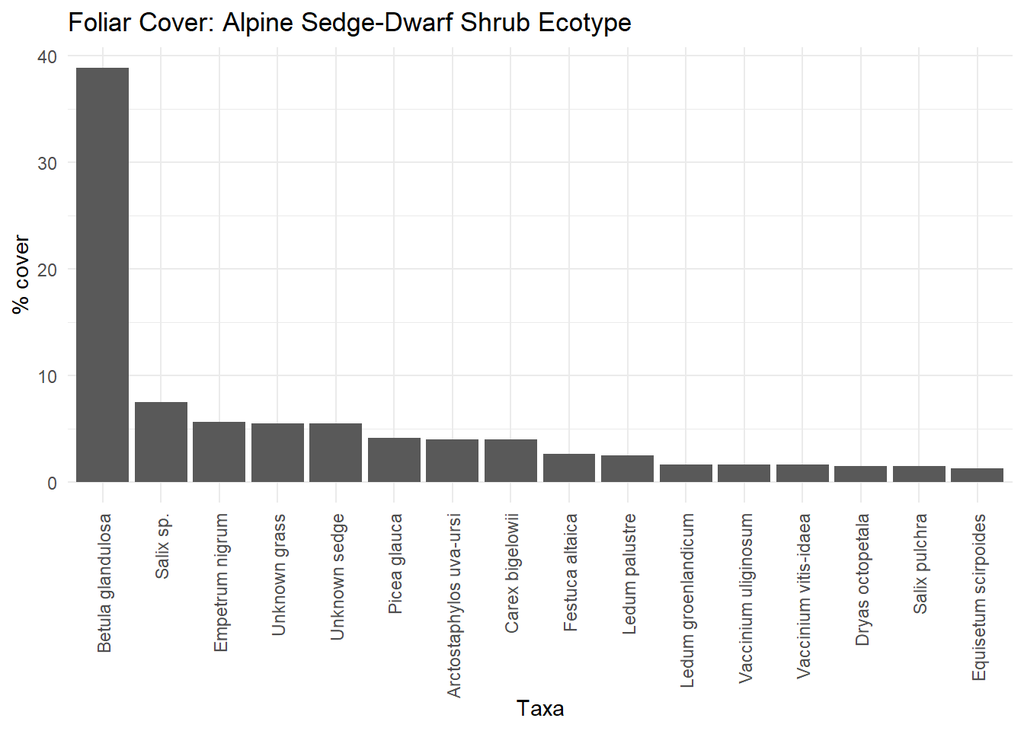

Figure 4 . Foliar percent cover in the Alpine Sedge-Dwarf Shrub ecotype having percent cover greater than 1%. X-axis taxa may include abiotic strata such as soil, litter or rock where no plant species were intercepted.

Table 13 . Foliar cover in the Alpine Sedge-Dwarf Shrub ecotype.

| ScientificName | Hits | Opportunities | % cover |
| --- | --- | --- | --- |
| Betula glandulosa | 233 | 600 | 38.8333333333333 |
| Salix sp. | 45 | 600 | 7.5 |
| Empetrum nigrum | 34 | 600 | 5.66666666666667 |
| Unknown grass | 33 | 600 | 5.5 |
| Unknown sedge | 33 | 600 | 5.5 |
| Picea glauca | 25 | 600 | 4.16666666666667 |
| Arctostaphylos uva-ursi | 24 | 600 | 4 |
| Carex bigelowii | 24 | 600 | 4 |
| Festuca altaica | 16 | 600 | 2.66666666666667 |
| Ledum palustre | 15 | 600 | 2.5 |
| Ledum groenlandicum | 10 | 600 | 1.66666666666667 |
| Vaccinium uliginosum | 10 | 600 | 1.66666666666667 |
| Vaccinium vitis-idaea | 10 | 600 | 1.66666666666667 |
| Dryas octopetala | 9 | 600 | 1.5 |
| Salix pulchra | 9 | 600 | 1.5 |
| Equisetum scirpoides | 8 | 600 | 1.33333333333333 |
| TOTAL | 538 |  | 89.6666666666667 |

## Mid-Story Cover

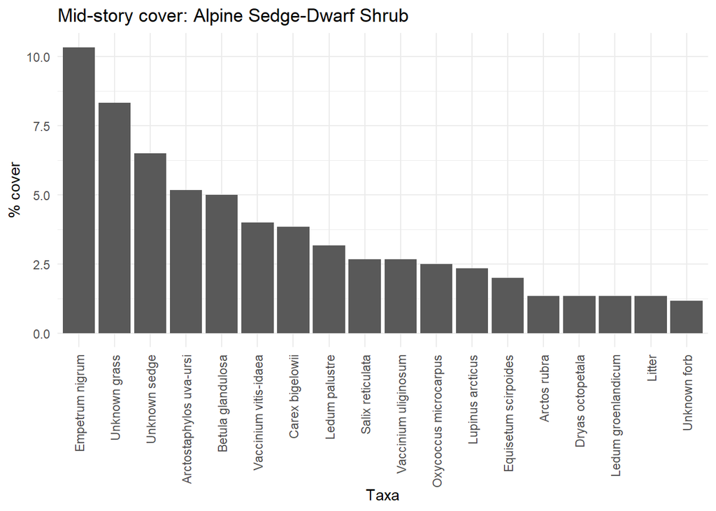

Figure 5 . Mid-story percent cover in the Alpine Sedge-Dwarf Shrub ecotype having percent cover greater than 1%. X-axis taxa may include abiotic strata such as soil, litter or rock where no plant species were intercepted.

Table 14 . Midstory cover in the Alpine Sedge-Dwarf Shrub ecotype.

| ScientificName | Hits | Opportunities | % cover |
| --- | --- | --- | --- |
| Empetrum nigrum | 62 | 600 | 10.3333333333333 |
| Unknown grass | 50 | 600 | 8.33333333333333 |
| Unknown sedge | 39 | 600 | 6.5 |
| Arctostaphylos uva-ursi | 31 | 600 | 5.16666666666667 |
| Betula glandulosa | 30 | 600 | 5 |
| Vaccinium vitis-idaea | 24 | 600 | 4 |
| Carex bigelowii | 23 | 600 | 3.83333333333333 |
| Ledum palustre | 19 | 600 | 3.16666666666667 |
| Salix reticulata | 16 | 600 | 2.66666666666667 |
| Vaccinium uliginosum | 16 | 600 | 2.66666666666667 |
| Oxycoccus microcarpus | 15 | 600 | 2.5 |
| Lupinus arcticus | 14 | 600 | 2.33333333333333 |
| Equisetum scirpoides | 12 | 600 | 2 |
| Arctos rubra | 8 | 600 | 1.33333333333333 |
| Dryas octopetala | 8 | 600 | 1.33333333333333 |
| Ledum groenlandicum | 8 | 600 | 1.33333333333333 |
| Litter | 8 | 600 | 1.33333333333333 |
| Unknown forb | 7 | 600 | 1.16666666666667 |
| TOTAL | 390 |  | 65 |

## Soil Surface Cover

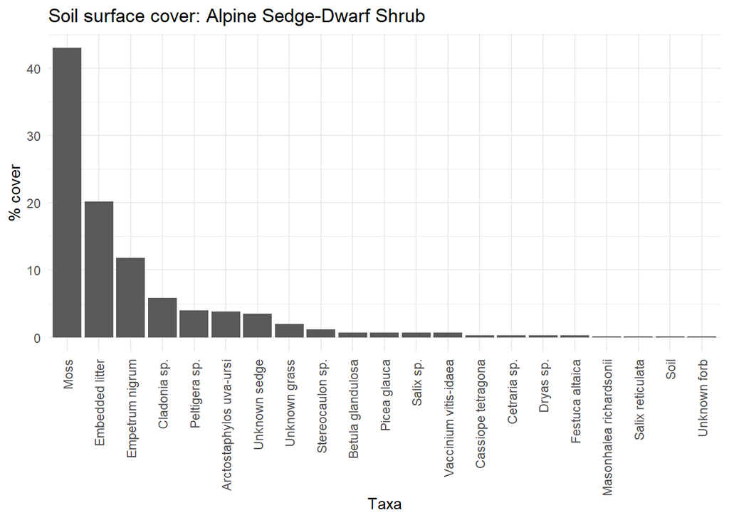

Table 15 . Soil surface cover in the Alpine Sedge-Dwarf Shrub ecotype.

| ScientificName | Hits | Opportunities | % cover |
| --- | --- | --- | --- |
| Moss | 258 | 600 | 43 |
| Embedded litter | 121 | 600 | 20.1666666666667 |
| Empetrum nigrum | 71 | 600 | 11.8333333333333 |
| Cladonia sp. | 35 | 600 | 5.83333333333333 |
| Peltigera sp. | 24 | 600 | 4 |
| Arctostaphylos uva-ursi | 23 | 600 | 3.83333333333333 |
| Unknown sedge | 21 | 600 | 3.5 |
| Unknown grass | 12 | 600 | 2 |
| Stereocaulon sp. | 7 | 600 | 1.16666666666667 |
| Betula glandulosa | 4 | 600 | 0.666666666666667 |
| Picea glauca | 4 | 600 | 0.666666666666667 |
| Salix sp. | 4 | 600 | 0.666666666666667 |
| Vaccinium vitis-idaea | 4 | 600 | 0.666666666666667 |
| Cassiope tetragona | 2 | 600 | 0.333333333333333 |
| Cetraria sp. | 2 | 600 | 0.333333333333333 |
| Dryas sp. | 2 | 600 | 0.333333333333333 |
| Festuca altaica | 2 | 600 | 0.333333333333333 |
| Masonhalea richardsonii | 1 | 600 | 0.166666666666667 |
| Salix reticulata | 1 | 600 | 0.166666666666667 |
| Soil | 1 | 600 | 0.166666666666667 |
| Unknown forb | 1 | 600 | 0.166666666666667 |
| TOTAL | 600 |  | 100 |

# Forest

## Distinguishing features and cover.

Common on or near overbank deposits; characterized by > 20% tree cover and thick mossy floor

The Forest ecotype covers approximately 4.6 % of the Chisana caribou herd range.

## Sampling Plots.

Table 12 . Plots And sampling dates in the Forest ecotype.

| Plot | Elevation (m) | Sampling Date |
| --- | --- | --- |
| WSP01 | 1011.8 | 2015-07-28 |

Mean elevation (m) = 1011.8 , number of plots = 1

## Foliar Cover

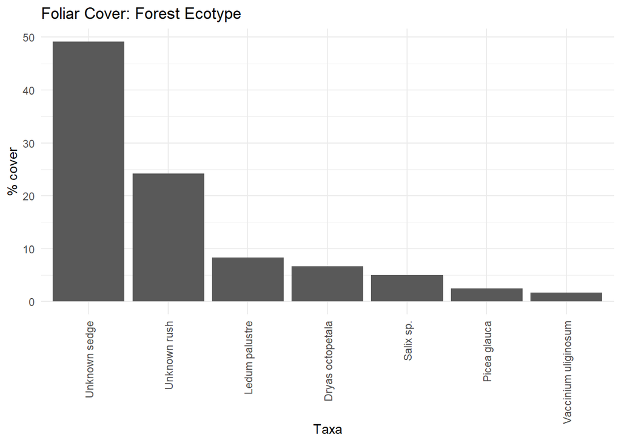

Figure 4 . Foliar percent cover in the Forest ecotype having percent cover greater than 1%. X-axis taxa may include abiotic strata such as soil, litter or rock where no plant species were intercepted.

Table 13 . Foliar cover in the Forest ecotype.

| ScientificName | Hits | Opportunities | % cover |
| --- | --- | --- | --- |
| Unknown sedge | 59 | 120 | 49.1666666666667 |
| Unknown rush | 29 | 120 | 24.1666666666667 |
| Ledum palustre | 10 | 120 | 8.33333333333333 |
| Dryas octopetala | 8 | 120 | 6.66666666666667 |
| Salix sp. | 6 | 120 | 5 |
| Picea glauca | 3 | 120 | 2.5 |
| Vaccinium uliginosum | 2 | 120 | 1.66666666666667 |
| TOTAL | 117 |  | 97.5 |

## Mid-Story Cover

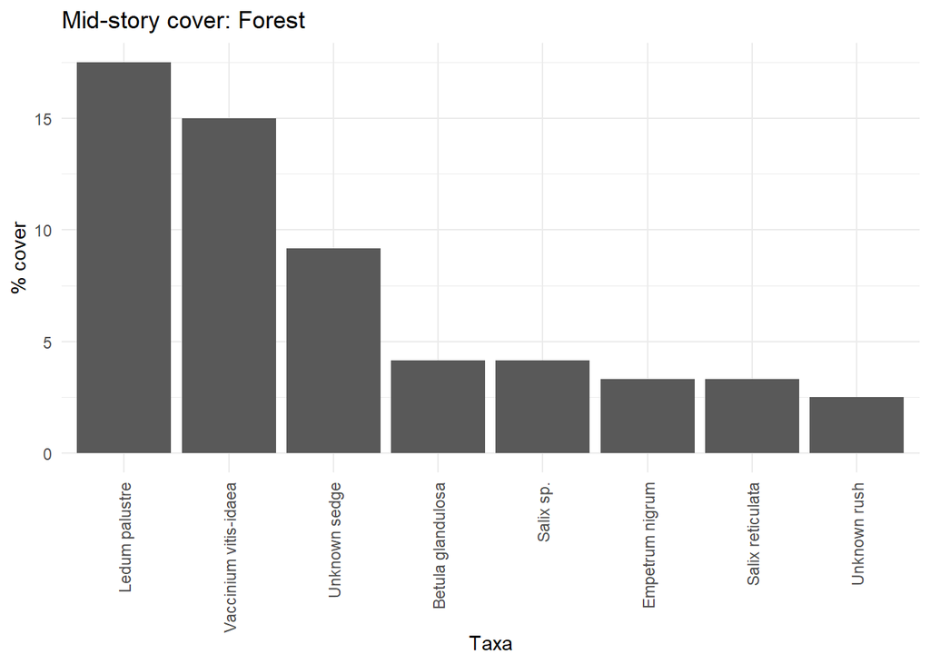

Figure 5 . Mid-story percent cover in the Forest ecotype having percent cover greater than 1%. X-axis taxa may include abiotic strata such as soil, litter or rock where no plant species were intercepted.

Table 14 . Midstory cover in the Forest ecotype.

| ScientificName | Hits | Opportunities | % cover |
| --- | --- | --- | --- |
| Ledum palustre | 21 | 120 | 17.5 |
| Vaccinium vitis-idaea | 18 | 120 | 15 |
| Unknown sedge | 11 | 120 | 9.16666666666667 |
| Betula glandulosa | 5 | 120 | 4.16666666666667 |
| Salix sp. | 5 | 120 | 4.16666666666667 |
| Empetrum nigrum | 4 | 120 | 3.33333333333333 |
| Salix reticulata | 4 | 120 | 3.33333333333333 |
| Unknown rush | 3 | 120 | 2.5 |
| TOTAL | 71 |  | 59.1666666666667 |

## Soil Surface Cover

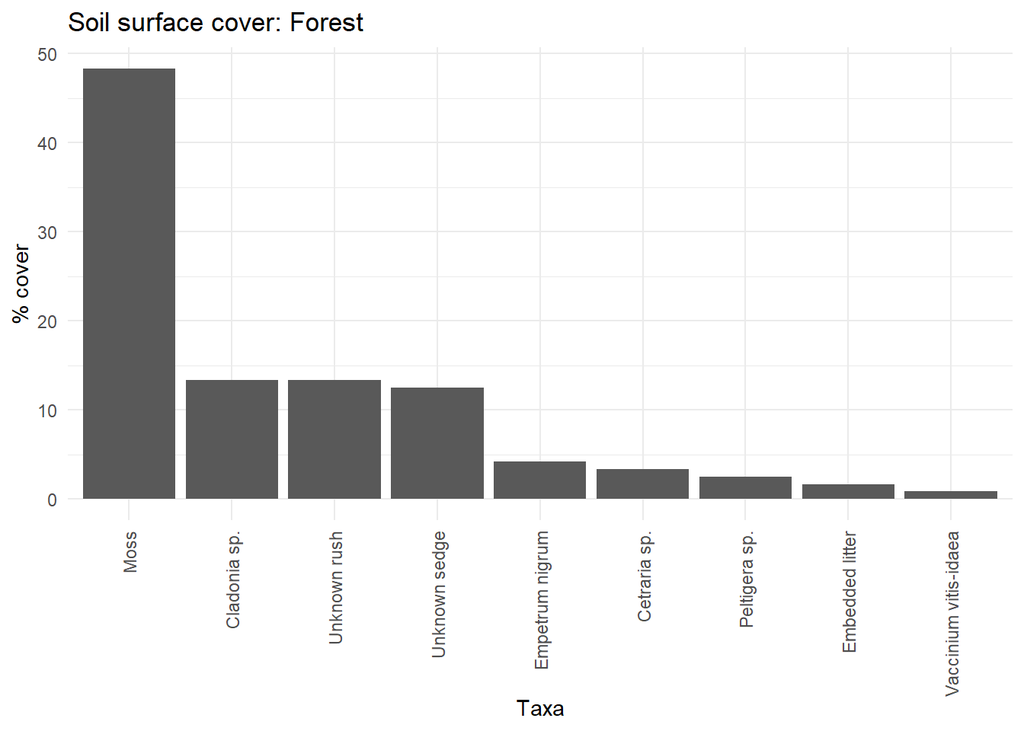

Table 15 . Soil surface cover in the Forest ecotype.

| ScientificName | Hits | Opportunities | % cover |
| --- | --- | --- | --- |
| Moss | 58 | 120 | 48.3333333333333 |
| Cladonia sp. | 16 | 120 | 13.3333333333333 |
| Unknown rush | 16 | 120 | 13.3333333333333 |
| Unknown sedge | 15 | 120 | 12.5 |
| Empetrum nigrum | 5 | 120 | 4.16666666666667 |
| Cetraria sp. | 4 | 120 | 3.33333333333333 |
| Peltigera sp. | 3 | 120 | 2.5 |
| Embedded litter | 2 | 120 | 1.66666666666667 |
| Vaccinium vitis-idaea | 1 | 120 | 0.833333333333333 |
| TOTAL | 120 |  | 100 |

# Riverine

## Sampling Plots.

Table 12 . Plots And sampling dates in the Riverine ecotype.

| Plot | Elevation (m) | Sampling Date |
| --- | --- | --- |
| RS03 | 1194.3 | 2015-07-11 |
| RS04 | 1332.8 | 2015-07-29 |
| RS05 | 1073.7 | 2015-07-11 |

Mean elevation (m) = 1200.3 , number of plots = 3

## Foliar Cover

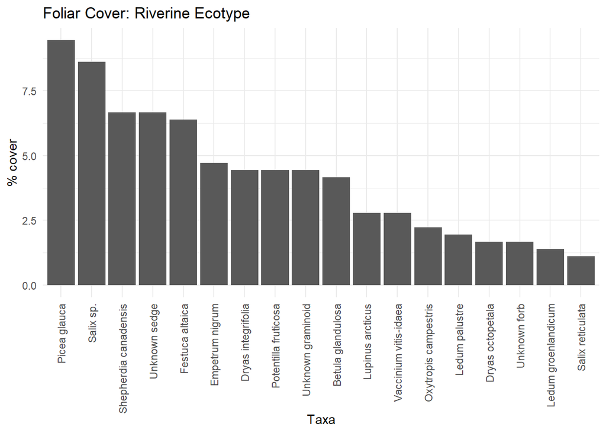

Figure 4 . Foliar percent cover in the Riverine ecotype having percent cover greater than 1%. X-axis taxa may include abiotic strata such as soil, litter or rock where no plant species were intercepted.

Table 13 . Foliar cover in the Riverine ecotype.

| ScientificName | Hits | Opportunities | % cover |
| --- | --- | --- | --- |
| Picea glauca | 34 | 360 | 9.44444444444444 |
| Salix sp. | 31 | 360 | 8.61111111111111 |
| Shepherdia canadensis | 24 | 360 | 6.66666666666667 |
| Unknown sedge | 24 | 360 | 6.66666666666667 |
| Festuca altaica | 23 | 360 | 6.38888888888889 |
| Empetrum nigrum | 17 | 360 | 4.72222222222222 |
| Dryas integrifolia | 16 | 360 | 4.44444444444444 |
| Potentilla fruticosa | 16 | 360 | 4.44444444444444 |
| Unknown graminoid | 16 | 360 | 4.44444444444444 |
| Betula glandulosa | 15 | 360 | 4.16666666666667 |
| Lupinus arcticus | 10 | 360 | 2.77777777777778 |
| Vaccinium vitis-idaea | 10 | 360 | 2.77777777777778 |
| Oxytropis campestris | 8 | 360 | 2.22222222222222 |
| Ledum palustre | 7 | 360 | 1.94444444444444 |
| Dryas octopetala | 6 | 360 | 1.66666666666667 |
| Unknown forb | 6 | 360 | 1.66666666666667 |
| Ledum groenlandicum | 5 | 360 | 1.38888888888889 |
| Salix reticulata | 4 | 360 | 1.11111111111111 |
| TOTAL | 272 |  | 75.5555555555556 |

## Mid-Story Cover

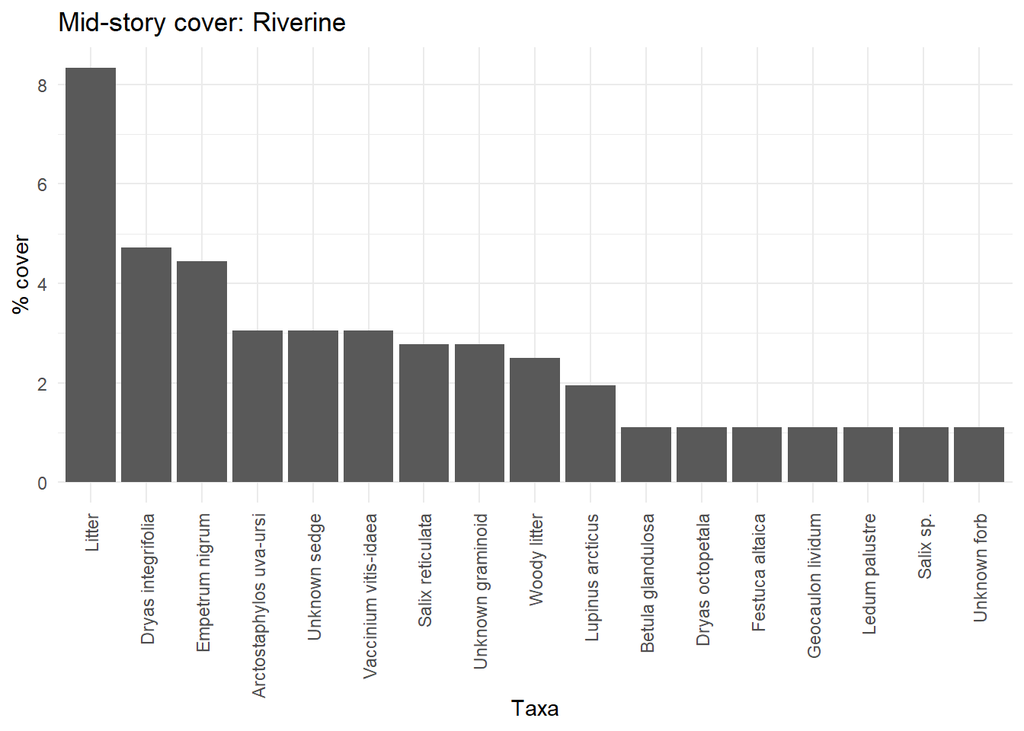

Figure 5 . Mid-story percent cover in the Riverine ecotype having percent cover greater than 1%. X-axis taxa may include abiotic strata such as soil, litter or rock where no plant species were intercepted.

Table 14 . Midstory cover in the Riverine ecotype.

| ScientificName | Hits | Opportunities | % cover |
| --- | --- | --- | --- |
| Litter | 30 | 360 | 8.33333333333333 |
| Dryas integrifolia | 17 | 360 | 4.72222222222222 |
| Empetrum nigrum | 16 | 360 | 4.44444444444444 |
| Arctostaphylos uva-ursi | 11 | 360 | 3.05555555555556 |
| Unknown sedge | 11 | 360 | 3.05555555555556 |
| Vaccinium vitis-idaea | 11 | 360 | 3.05555555555556 |
| Salix reticulata | 10 | 360 | 2.77777777777778 |
| Unknown graminoid | 10 | 360 | 2.77777777777778 |
| Woody litter | 9 | 360 | 2.5 |
| Lupinus arcticus | 7 | 360 | 1.94444444444444 |
| Betula glandulosa | 4 | 360 | 1.11111111111111 |
| Dryas octopetala | 4 | 360 | 1.11111111111111 |
| Festuca altaica | 4 | 360 | 1.11111111111111 |
| Geocaulon lividum | 4 | 360 | 1.11111111111111 |
| Ledum palustre | 4 | 360 | 1.11111111111111 |
| Salix sp. | 4 | 360 | 1.11111111111111 |
| Unknown forb | 4 | 360 | 1.11111111111111 |
| TOTAL | 160 |  | 44.4444444444444 |

## Soil Surface Cover

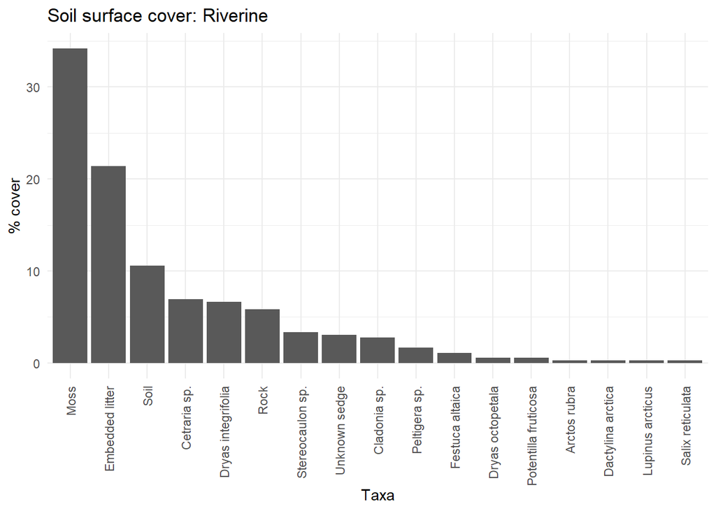

Table 15 . Soil surface cover in the Riverine ecotype.

| ScientificName | Hits | Opportunities | % cover |
| --- | --- | --- | --- |
| Moss | 123 | 360 | 34.1666666666667 |
| Embedded litter | 77 | 360 | 21.3888888888889 |
| Soil | 38 | 360 | 10.5555555555556 |
| Cetraria sp. | 25 | 360 | 6.94444444444444 |
| Dryas integrifolia | 24 | 360 | 6.66666666666667 |
| Rock | 21 | 360 | 5.83333333333333 |
| Stereocaulon sp. | 12 | 360 | 3.33333333333333 |
| Unknown sedge | 11 | 360 | 3.05555555555556 |
| Cladonia sp. | 10 | 360 | 2.77777777777778 |
| Peltigera sp. | 6 | 360 | 1.66666666666667 |
| Festuca altaica | 4 | 360 | 1.11111111111111 |
| Dryas octopetala | 2 | 360 | 0.555555555555556 |
| Potentilla fruticosa | 2 | 360 | 0.555555555555556 |
| Arctos rubra | 1 | 360 | 0.277777777777778 |
| Dactylina arctica | 1 | 360 | 0.277777777777778 |
| Lupinus arcticus | 1 | 360 | 0.277777777777778 |
| Salix reticulata | 1 | 360 | 0.277777777777778 |
| TOTAL | 359 |  | 99.7222222222222 |

# Subalpine Wood/Shrub

## Distinguishing features and cover.

Common on or near overbank deposits; characterized by > 20% tree cover and thick mossy floor

The Subalpine Wood/Shrub ecotype covers approximately 4.6 % of the Chisana caribou herd range.

## Sampling Plots.

Table 12 . Plots And sampling dates in the Subalpine Wood/Shrub ecotype.

| Plot | Elevation (m) | Sampling Date |
| --- | --- | --- |
| SWB01 | 1316.7 | 2015-07-28 |
| SWB06 | 1560.1 | 2016-07-16 |
| SWB07 | 1478.4 | 2015-07-21 |
| SWB08 | 1307.9 | 2016-07-17 |
| SWB09 | 1182.4 | 2015-07-11 |
| SWB10 | 1209.7 | 2015-07-12 |
| SWB12 | 1403.9 | 2015-07-26 |
| SWB14 | 1232.5 | 2015-07-13 |
| SWB15 | 1508.8 | 2016-07-16 |

Mean elevation (m) = 1355.6 , number of plots = 9

## Foliar Cover

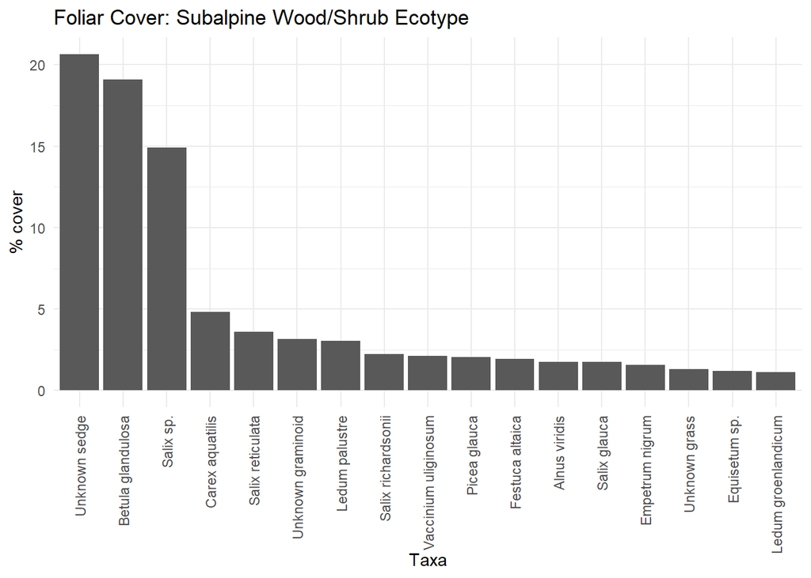

Figure 4 . Foliar percent cover in the Subalpine Wood/Shrub ecotype having percent cover greater than 1%. X-axis taxa may include abiotic strata such as soil, litter or rock where no plant species were intercepted.

Table 13 . Foliar cover in the Subalpine Wood/Shrub ecotype.

| ScientificName | Hits | Opportunities | % cover |
| --- | --- | --- | --- |
| Unknown sedge | 223 | 1080 | 20.6481481481481 |
| Betula glandulosa | 206 | 1080 | 19.0740740740741 |
| Salix sp. | 161 | 1080 | 14.9074074074074 |
| Carex aquatilis | 52 | 1080 | 4.81481481481481 |
| Salix reticulata | 39 | 1080 | 3.61111111111111 |
| Unknown graminoid | 34 | 1080 | 3.14814814814815 |
| Ledum palustre | 33 | 1080 | 3.05555555555556 |
| Salix richardsonii | 24 | 1080 | 2.22222222222222 |
| Vaccinium uliginosum | 23 | 1080 | 2.12962962962963 |
| Picea glauca | 22 | 1080 | 2.03703703703704 |
| Festuca altaica | 21 | 1080 | 1.94444444444444 |
| Alnus viridis | 19 | 1080 | 1.75925925925926 |
| Salix glauca | 19 | 1080 | 1.75925925925926 |
| Empetrum nigrum | 17 | 1080 | 1.57407407407407 |
| Unknown grass | 14 | 1080 | 1.2962962962963 |
| Equisetum sp. | 13 | 1080 | 1.2037037037037 |
| Ledum groenlandicum | 12 | 1080 | 1.11111111111111 |
| TOTAL | 932 |  | 86.2962962962963 |

## Mid-Story Cover

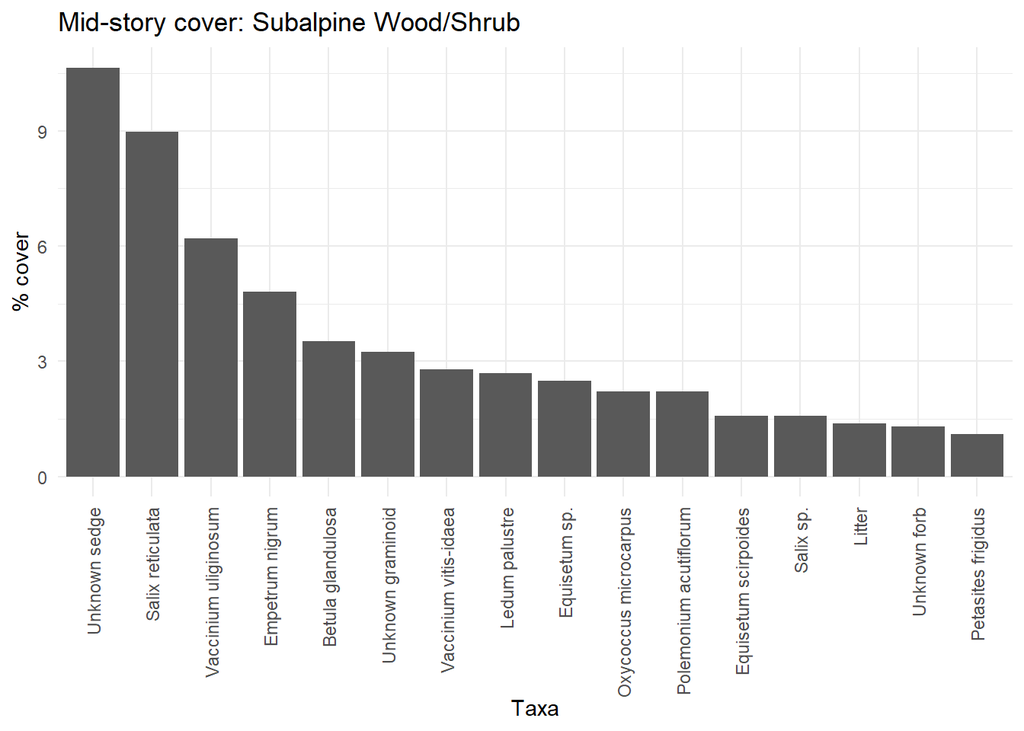

Figure 5 . Mid-story percent cover in the Subalpine Wood/Shrub ecotype having percent cover greater than 1%. X-axis taxa may include abiotic strata such as soil, litter or rock where no plant species were intercepted.

Table 14 . Midstory cover in the Subalpine Wood/Shrub ecotype.

| ScientificName | Hits | Opportunities | % cover |
| --- | --- | --- | --- |
| Unknown sedge | 115 | 1080 | 10.6481481481481 |
| Salix reticulata | 97 | 1080 | 8.98148148148148 |
| Vaccinium uliginosum | 67 | 1080 | 6.2037037037037 |
| Empetrum nigrum | 52 | 1080 | 4.81481481481481 |
| Betula glandulosa | 38 | 1080 | 3.51851851851852 |
| Unknown graminoid | 35 | 1080 | 3.24074074074074 |
| Vaccinium vitis-idaea | 30 | 1080 | 2.77777777777778 |
| Ledum palustre | 29 | 1080 | 2.68518518518519 |
| Equisetum sp. | 27 | 1080 | 2.5 |
| Oxycoccus microcarpus | 24 | 1080 | 2.22222222222222 |
| Polemonium acutiflorum | 24 | 1080 | 2.22222222222222 |
| Equisetum scirpoides | 17 | 1080 | 1.57407407407407 |
| Salix sp. | 17 | 1080 | 1.57407407407407 |
| Litter | 15 | 1080 | 1.38888888888889 |
| Unknown forb | 14 | 1080 | 1.2962962962963 |
| Petasites frigidus | 12 | 1080 | 1.11111111111111 |
| TOTAL | 613 |  | 56.7592592592593 |

## Soil Surface Cover

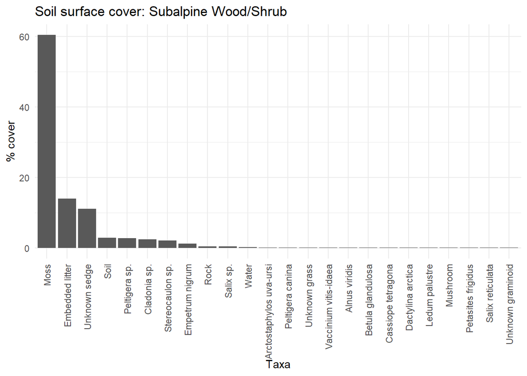

Table 15 . Soil surface cover in the Subalpine Wood/Shrub ecotype.

| ScientificName | Hits | Opportunities | % cover |
| --- | --- | --- | --- |
| Moss | 653 | 1080 | 60.462962962963 |
| Embedded litter | 152 | 1080 | 14.0740740740741 |
| Unknown sedge | 120 | 1080 | 11.1111111111111 |
| Soil | 31 | 1080 | 2.87037037037037 |
| Peltigera sp. | 30 | 1080 | 2.77777777777778 |
| Cladonia sp. | 27 | 1080 | 2.5 |
| Stereocaulon sp. | 23 | 1080 | 2.12962962962963 |
| Empetrum nigrum | 14 | 1080 | 1.2962962962963 |
| Rock | 5 | 1080 | 0.462962962962963 |
| Salix sp. | 5 | 1080 | 0.462962962962963 |
| Water | 3 | 1080 | 0.277777777777778 |
| Arctostaphylos uva-ursi | 2 | 1080 | 0.185185185185185 |
| Peltigera canina | 2 | 1080 | 0.185185185185185 |
| Unknown grass | 2 | 1080 | 0.185185185185185 |
| Vaccinium vitis-idaea | 2 | 1080 | 0.185185185185185 |
| Alnus viridis | 1 | 1080 | 0.0925925925925926 |
| Betula glandulosa | 1 | 1080 | 0.0925925925925926 |
| Cassiope tetragona | 1 | 1080 | 0.0925925925925926 |
| Dactylina arctica | 1 | 1080 | 0.0925925925925926 |
| Ledum palustre | 1 | 1080 | 0.0925925925925926 |
| Mushroom | 1 | 1080 | 0.0925925925925926 |
| Petasites frigidus | 1 | 1080 | 0.0925925925925926 |
| Salix reticulata | 1 | 1080 | 0.0925925925925926 |
| Unknown graminoid | 1 | 1080 | 0.0925925925925926 |
| TOTAL | 1080 |  | 100 |

# Appendix B: Fecal Pellet Results By Sample

## Fecal Pellet Sample 1201617

Fecal pellet composition summary:

Table 12 . Fecal pellect composition, 1201617

| Plant | Form | Mean % composition |
| --- | --- | --- |
| Cladonia/Cladina lichens | Lichen | 37.7 |
| Classic Moss | Moss | 19.7 |
| Alectoria/Bryoria lichen | Lichen | 10.6 |
| Carex spp. | Sedge/Rush | 7.3 |
| Cetraria/Dactylina lichens | Lichen | 6.6 |
| Aulacomnium Moss | Moss | 4.1 |
| Equisetum spp. | Forb | 3.7 |
| Foliose lichen | Lichen | 3.3 |
| Poa arctica | Grass | 1.9 |
| Empetrum nigrum leaf | Shrub | 1.4 |
| Sphagnum sp. Moss | Moss | 1.2 |
| Stereocaulon sp. lichen | Lichen | 0.7 |
| Juncus castaneus | Sedge/Rush | 0.6 |
| Anthoxanthum monticola | Grass | 0.4 |
| Eriophorum spp. | Sedge/Rush | 0.4 |
| Betula spp. stem | Shrub | 0.4 |

## Fecal Pellet Sample 1201618

Fecal pellet composition summary:

Table 12 . Fecal pellect composition, 1201618

| Plant | Form | Mean % composition |
| --- | --- | --- |
| Classic Moss | Moss | 29.3 |
| Cladonia/Cladina lichens | Lichen | 25.4 |
| Alectoria/Bryoria lichen | Lichen | 11.7 |
| Carex spp. | Sedge/Rush | 9.0 |
| Cetraria/Dactylina lichens | Lichen | 6.1 |
| Foliose lichen | Lichen | 3.3 |
| Empetrum nigrum leaf | Shrub | 2.2 |
| Aulacomnium Moss | Moss | 1.7 |
| Equisetum spp. | Forb | 1.3 |
| Arctagrostis latifolia | Grass | 0.9 |
| Festuca altaica | Grass | 0.9 |
| Sphagnum sp. Moss | Moss | 0.9 |
| Dryas spp. stem | Shrub | 0.8 |
| Salix spp. stem | Shrub | 0.8 |
| Lupinus arcticus | Forb | 0.7 |
| Calamagrostis canadensis | Grass | 0.6 |
| Stereocaulon sp. lichen | Lichen | 0.6 |
| Betula spp. stem | Shrub | 0.6 |
| Cassiope tetragona stem | Shrub | 0.6 |
| Unknown Shrub leaves | Shrub | 0.5 |
| Minuartia obtusiloba | Forb | 0.3 |
| Anthoxanthum monticola | Grass | 0.3 |
| Nephroma arcticum lichen | Lichen | 0.3 |
| Cassiope tetragona leaf | Shrub | 0.3 |
| Empetrum nigrum stem | Shrub | 0.3 |
| Ledum spp. leaf | Shrub | 0.3 |
| Salix spp. leaf | Shrub | 0.3 |

## Fecal Pellet Sample 1201619

Fecal pellet composition summary:

Table 12 . Fecal pellect composition, 1201619

| Plant | Form | Mean % composition |
| --- | --- | --- |
| Classic Moss | Moss | 36.1 |
| Cladonia/Cladina lichens | Lichen | 24.8 |
| Alectoria/Bryoria lichen | Lichen | 8.5 |
| Cetraria/Dactylina lichens | Lichen | 8.5 |
| Carex spp. | Sedge/Rush | 5.7 |
| Equisetum spp. | Forb | 3.6 |
| Foliose lichen | Lichen | 2.7 |
| Sphagnum sp. Moss | Moss | 1.8 |
| Salix spp. stem | Shrub | 1.5 |
| Dryas spp. stem | Shrub | 1.4 |
| Aulacomnium Moss | Moss | 0.9 |
| Dryas spp. leaf | Shrub | 0.8 |
| Poa arctica | Grass | 0.6 |
| Unknown Forbs | Forb | 0.5 |
| Empetrum nigrum leaf | Shrub | 0.5 |
| Unknown Shrub stems | Shrub | 0.5 |
| Lupinus arcticus | Forb | 0.4 |
| Anthoxanthum monticola | Grass | 0.3 |
| Juncus castaneus | Sedge/Rush | 0.3 |
| Oxytropis spp. | Forb | 0.2 |
| Calamagrostis canadensis | Grass | 0.1 |
| Stereocaulon sp. lichen | Lichen | 0.1 |
| Polytrichum juniperinum | Moss | 0.1 |
| Ledum spp. leaf | Shrub | 0.1 |

## Fecal Pellet Sample 1201620

Fecal pellet composition summary:

Table 12 . Fecal pellect composition, 1201620

| Plant | Form | Mean % composition |
| --- | --- | --- |
| Cladonia/Cladina lichens | Lichen | 26.4 |
| Classic Moss | Moss | 22.4 |
| Cetraria/Dactylina lichens | Lichen | 10.3 |
| Alectoria/Bryoria lichen | Lichen | 9.7 |
| Foliose lichen | Lichen | 7.0 |
| Carex spp. | Sedge/Rush | 7.0 |
| Equisetum spp. | Forb | 4.0 |
| Aulacomnium Moss | Moss | 3.7 |
| Arctagrostis latifolia | Grass | 1.0 |
| Salix spp. leaf | Shrub | 0.9 |
| Astragalus sp. | Forb | 0.7 |
| Anthoxanthum monticola | Grass | 0.7 |
| Polytrichum juniperinum | Moss | 0.7 |
| Sphagnum sp. Moss | Moss | 0.7 |
| Poa arctica | Grass | 0.6 |
| Betula spp. stem | Shrub | 0.6 |
| Lupinus arcticus | Forb | 0.5 |
| Cassiope tetragona leaf | Shrub | 0.5 |
| Dryas spp. leaf | Shrub | 0.4 |
| Salix spp. stem | Shrub | 0.4 |
| Calamagrostis canadensis | Grass | 0.3 |
| Stereocaulon sp. lichen | Lichen | 0.3 |
| Ledum spp. leaf | Shrub | 0.3 |
| Populus balsamifera stem | Shrub | 0.3 |
| Minuartia obtusiloba | Forb | 0.2 |
| Oxytropis spp. | Forb | 0.2 |
| Nephroma arcticum lichen | Lichen | 0.2 |

## Fecal Pellet Sample 1201621

Fecal pellet composition summary:

Table 12 . Fecal pellect composition, 1201621

| Plant | Form | Mean % composition |
| --- | --- | --- |
| Classic Moss | Moss | 33.8 |
| Cladonia/Cladina lichens | Lichen | 29.5 |
| Equisetum spp. | Forb | 8.8 |
| Cetraria/Dactylina lichens | Lichen | 7.3 |
| Alectoria/Bryoria lichen | Lichen | 5.4 |
| Aulacomnium Moss | Moss | 4.5 |
| Carex spp. | Sedge/Rush | 4.2 |
| Foliose lichen | Lichen | 2.6 |
| Stereocaulon sp. lichen | Lichen | 1.6 |
| Calamagrostis canadensis | Grass | 0.4 |
| Betula spp. stem | Shrub | 0.4 |
| Sphagnum sp. Moss | Moss | 0.3 |
| Juncus castaneus | Sedge/Rush | 0.3 |
| Dryas spp. stem | Shrub | 0.3 |
| Lupinus arcticus | Forb | 0.2 |
| Arctagrostis latifolia | Grass | 0.2 |
| Dryas spp. leaf | Shrub | 0.2 |

## Fecal Pellet Sample 1201622

Fecal pellet composition summary:

Table 12 . Fecal pellect composition, 1201622

| Plant | Form | Mean % composition |
| --- | --- | --- |
| Classic Moss | Moss | 32.6 |
| Cladonia/Cladina lichens | Lichen | 23.4 |
| Equisetum spp. | Forb | 8.9 |
| Cetraria/Dactylina lichens | Lichen | 7.2 |
| Carex spp. | Sedge/Rush | 6.2 |
| Alectoria/Bryoria lichen | Lichen | 5.1 |
| Dryas spp. leaf | Shrub | 4.3 |
| Foliose lichen | Lichen | 2.9 |
| Aulacomnium Moss | Moss | 2.4 |
| Sphagnum sp. Moss | Moss | 1.3 |
| Lupinus arcticus | Forb | 1.2 |
| Salix spp. stem | Shrub | 1.2 |
| Salix spp. leaf | Shrub | 1.1 |
| Empetrum nigrum leaf | Shrub | 0.8 |
| Stereocaulon sp. lichen | Lichen | 0.4 |
| Juncus castaneus | Sedge/Rush | 0.4 |
| Arctagrostis latifolia | Grass | 0.3 |
| Polytrichum juniperinum | Moss | 0.3 |

## Fecal Pellet Sample 1201623

Fecal pellet composition summary:

Table 12 . Fecal pellect composition, 1201623

| Plant | Form | Mean % composition |
| --- | --- | --- |
| Cladonia/Cladina lichens | Lichen | 36.4 |
| Classic Moss | Moss | 24.3 |
| Alectoria/Bryoria lichen | Lichen | 7.6 |
| Cetraria/Dactylina lichens | Lichen | 6.7 |
| Carex spp. | Sedge/Rush | 6.3 |
| Equisetum spp. | Forb | 4.3 |
| Aulacomnium Moss | Moss | 2.7 |
| Sphagnum sp. Moss | Moss | 1.8 |
| Foliose lichen | Lichen | 1.6 |
| Stereocaulon sp. lichen | Lichen | 1.0 |
| Empetrum nigrum leaf | Shrub | 1.0 |
| Salix spp. leaf | Shrub | 1.0 |
| Anthoxanthum monticola | Grass | 0.7 |
| Populus balsamifera stem | Shrub | 0.7 |
| Calamagrostis canadensis | Grass | 0.6 |
| Dasiphora (Potentilla) fruticosa | Forb | 0.5 |
| Lupinus arcticus | Forb | 0.5 |
| Oxycoccus macrocarpus | Forb | 0.3 |
| Poa arctica | Grass | 0.3 |
| Juncus castaneus | Sedge/Rush | 0.3 |
| Dryas spp. stem | Shrub | 0.3 |
| Unknown Shrub stems | Shrub | 0.3 |
| Arctagrostis latifolia | Grass | 0.2 |
| Unknown Grasses | Grass | 0.2 |
| Polytrichum juniperinum | Moss | 0.2 |
| Ledum spp. leaf | Shrub | 0.2 |

## Fecal Pellet Sample 2201506

Fecal pellet composition summary:

Table 12 . Fecal pellect composition, 2201506

| Plant | Form | Mean % composition |
| --- | --- | --- |
| Cladonia/Cladina lichens | Lichen | 29.3 |
| Classic Moss | Moss | 24.0 |
| Carex spp. | Sedge/Rush | 7.9 |
| Aulacomnium Moss | Moss | 7.3 |
| Alectoria/Bryoria lichen | Lichen | 6.5 |
| Cetraria/Dactylina lichens | Lichen | 5.6 |
| Foliose lichen | Lichen | 3.6 |
| Polytrichum juniperinum | Moss | 3.4 |
| Equisetum spp. | Forb | 1.9 |
| Betula spp. stem | Shrub | 1.7 |
| Poa arctica | Grass | 1.4 |
| Salix spp. stem | Shrub | 1.3 |
| Stereocaulon sp. lichen | Lichen | 1.0 |
| Nephroma arcticum lichen | Lichen | 0.7 |
| Empetrum nigrum leaf | Shrub | 0.7 |
| Vaccinium spp. stem | Shrub | 0.7 |
| Arctagrostis latifolia | Grass | 0.6 |
| Sphagnum sp. Moss | Moss | 0.6 |
| Unknown Shrub leaves | Shrub | 0.6 |
| Kobresia simpliciuscula | Sedge/Rush | 0.4 |
| Juncus castaneus | Sedge/Rush | 0.3 |
| Unknown Shrub stems | Shrub | 0.3 |
| Polygonum spp. | Forb | 0.1 |
| Anthoxanthum monticola | Grass | 0.1 |

## Fecal Pellet Sample 2201507

Fecal pellet composition summary:

Table 12 . Fecal pellect composition, 2201507

| Plant | Form | Mean % composition |
| --- | --- | --- |
| Classic Moss | Moss | 35.0 |
| Cladonia/Cladina lichens | Lichen | 23.3 |
| Cetraria/Dactylina lichens | Lichen | 7.8 |
| Alectoria/Bryoria lichen | Lichen | 7.2 |
| Foliose lichen | Lichen | 5.7 |
| Betula spp. stem | Shrub | 5.1 |
| Carex spp. | Sedge/Rush | 4.5 |
| Aulacomnium Moss | Moss | 2.4 |
| Polytrichum juniperinum | Moss | 0.9 |
| Juncus castaneus | Sedge/Rush | 0.9 |
| Arctagrostis latifolia | Grass | 0.7 |
| Poa arctica | Grass | 0.7 |
| Unknown Shrub leaves | Shrub | 0.7 |
| Vaccinium spp. stem | Shrub | 0.7 |
| Equisetum spp. | Forb | 0.6 |
| Anthoxanthum monticola | Grass | 0.6 |
| Nephroma arcticum lichen | Lichen | 0.6 |
| Populus balsamifera leaf | Shrub | 0.6 |
| Salix spp. leaf | Shrub | 0.6 |
| Ledum spp. leaf | Shrub | 0.4 |
| Lycopodium annotinum | Moss | 0.3 |
| Salix spp. stem | Shrub | 0.3 |
| Astragalus sp. | Forb | 0.1 |
| Unknown Forbs | Forb | 0.1 |
| Stereocaulon sp. lichen | Lichen | 0.1 |
| Sphagnum sp. Moss | Moss | 0.1 |

## Fecal Pellet Sample 2201508

Fecal pellet composition summary:

Table 12 . Fecal pellect composition, 2201508

| Plant | Form | Mean % composition |
| --- | --- | --- |
| Cladonia/Cladina lichens | Lichen | 26.6 |
| Classic Moss | Moss | 22.7 |
| Cetraria/Dactylina lichens | Lichen | 9.9 |
| Foliose lichen | Lichen | 8.3 |
| Alectoria/Bryoria lichen | Lichen | 6.9 |
| Sphagnum sp. Moss | Moss | 3.5 |
| Equisetum spp. | Forb | 3.0 |
| Poa arctica | Grass | 2.9 |
| Carex spp. | Sedge/Rush | 2.7 |
| Empetrum nigrum leaf | Shrub | 2.3 |
| Stereocaulon sp. lichen | Lichen | 1.8 |
| Arctagrostis latifolia | Grass | 1.5 |
| Aulacomnium Moss | Moss | 1.1 |
| Unknown Shrub leaves | Shrub | 1.1 |
| Astragalus sp. | Forb | 0.8 |
| Dryas spp. leaf | Shrub | 0.8 |
| Minuartia obtusiloba | Forb | 0.7 |
| Rubus spp. stem | Shrub | 0.7 |
| Unknown Shrub stems | Shrub | 0.7 |
| Polytrichum juniperinum | Moss | 0.4 |
| Salix spp. leaf | Shrub | 0.4 |
| Lupinus arcticus | Forb | 0.3 |
| Juncus castaneus | Sedge/Rush | 0.3 |
| Ledum spp. leaf | Shrub | 0.3 |
| Populus balsamifera leaf | Shrub | 0.3 |

## Fecal Pellet Sample 2201509

Fecal pellet composition summary:

Table 12 . Fecal pellect composition, 2201509

| Plant | Form | Mean % composition |
| --- | --- | --- |
| Classic Moss | Moss | 28.3 |
| Cladonia/Cladina lichens | Lichen | 17.7 |
| Cetraria/Dactylina lichens | Lichen | 11.5 |
| Foliose lichen | Lichen | 7.4 |
| Alectoria/Bryoria lichen | Lichen | 5.3 |
| Poa arctica | Grass | 4.6 |
| Dryas spp. leaf | Shrub | 4.2 |
| Empetrum nigrum leaf | Shrub | 3.9 |
| Salix spp. leaf | Shrub | 3.0 |
| Aulacomnium Moss | Moss | 2.8 |
| Equisetum spp. | Forb | 1.9 |
| Carex spp. | Sedge/Rush | 1.8 |
| Sphagnum sp. Moss | Moss | 1.4 |
| Calamagrostis canadensis | Grass | 1.2 |
| Dryas spp. stem | Shrub | 0.7 |
| Populus balsamifera leaf | Shrub | 0.7 |
| Unknown Shrub leaves | Shrub | 0.7 |
| Lupinus arcticus | Forb | 0.5 |
| Anthoxanthum monticola | Grass | 0.5 |
| Salix spp. stem | Shrub | 0.5 |
| Astragalus sp. | Forb | 0.4 |
| Nephroma arcticum lichen | Lichen | 0.4 |
| Ledum spp. leaf | Shrub | 0.4 |
| Stereocaulon sp. lichen | Lichen | 0.2 |

## Fecal Pellet Sample 2201601

Fecal pellet composition summary:

Table 12 . Fecal pellect composition, 2201601

| Plant | Form | Mean % composition |
| --- | --- | --- |
| Cladonia/Cladina lichens | Lichen | 40.3 |
| Classic Moss | Moss | 19.3 |
| Cetraria/Dactylina lichens | Lichen | 6.2 |
| Alectoria/Bryoria lichen | Lichen | 6.0 |
| Aulacomnium Moss | Moss | 5.8 |
| Equisetum spp. | Forb | 5.0 |
| Carex spp. | Sedge/Rush | 4.9 |
| Foliose lichen | Lichen | 4.2 |
| Polytrichum juniperinum | Moss | 1.8 |
| Stereocaulon sp. lichen | Lichen | 1.6 |
| Poa arctica | Grass | 1.4 |
| Anthoxanthum monticola | Grass | 0.7 |
| Unknown Grasses | Grass | 0.5 |
| Sphagnum sp. Moss | Moss | 0.5 |
| Minuartia obtusiloba | Forb | 0.4 |
| Eriophorum spp. | Sedge/Rush | 0.4 |
| Betula spp. stem | Shrub | 0.4 |
| Empetrum nigrum leaf | Shrub | 0.4 |
| Salix spp. stem | Shrub | 0.2 |

## Fecal Pellet Sample 2201602

Fecal pellet composition summary:

Table 12 . Fecal pellect composition, 2201602

| Plant | Form | Mean % composition |
| --- | --- | --- |
| Cladonia/Cladina lichens | Lichen | 32.5 |
| Classic Moss | Moss | 26.5 |
| Cetraria/Dactylina lichens | Lichen | 11.6 |
| Alectoria/Bryoria lichen | Lichen | 6.1 |
| Aulacomnium Moss | Moss | 4.6 |
| Foliose lichen | Lichen | 4.3 |
| Carex spp. | Sedge/Rush | 4.1 |
| Equisetum spp. | Forb | 3.2 |
| Sphagnum sp. Moss | Moss | 1.1 |
| Poa arctica | Grass | 0.8 |
| Juncus castaneus | Sedge/Rush | 0.7 |
| Unknown Forbs | Forb | 0.5 |
| Arctagrostis latifolia | Grass | 0.5 |
| Stereocaulon sp. lichen | Lichen | 0.5 |
| Empetrum nigrum stem | Shrub | 0.5 |
| Dryas spp. leaf | Shrub | 0.4 |
| Stellaria longipes | Forb | 0.3 |
| Festuca altaica | Grass | 0.3 |
| Polytrichum juniperinum | Moss | 0.3 |
| Betula spp. stem | Shrub | 0.3 |
| Unknown Shrub leaves | Shrub | 0.3 |
| Dasiphora (Potentilla) fruticosa | Forb | 0.2 |
| Nephroma arcticum lichen | Lichen | 0.2 |
| Dryas spp. stem | Shrub | 0.2 |

## Fecal Pellet Sample 2201603

Fecal pellet composition summary:

Table 12 . Fecal pellect composition, 2201603

| Plant | Form | Mean % composition |
| --- | --- | --- |
| Classic Moss | Moss | 41.3 |
| Cladonia/Cladina lichens | Lichen | 16.8 |
| Carex spp. | Sedge/Rush | 7.7 |
| Cetraria/Dactylina lichens | Lichen | 6.9 |
| Alectoria/Bryoria lichen | Lichen | 6.2 |
| Foliose lichen | Lichen | 4.2 |
| Dryas spp. leaf | Shrub | 3.0 |
| Poa arctica | Grass | 2.5 |
| Aulacomnium Moss | Moss | 2.0 |
| Salix spp. leaf | Shrub | 2.0 |
| Oxytropis spp. | Forb | 1.4 |
| Populus balsamifera stem | Shrub | 0.9 |
| Lupinus arcticus | Forb | 0.8 |
| Empetrum nigrum leaf | Shrub | 0.7 |
| Dasiphora (Potentilla) fruticosa | Forb | 0.5 |
| Arctagrostis latifolia | Grass | 0.5 |
| Dryas spp. stem | Shrub | 0.5 |
| Anthoxanthum monticola | Grass | 0.4 |
| Stereocaulon sp. lichen | Lichen | 0.4 |
| Eriophorum spp. | Sedge/Rush | 0.3 |
| Ledum spp. leaf | Shrub | 0.3 |
| Unknown Shrub stems | Shrub | 0.3 |
| Oxycoccus macrocarpus | Forb | 0.2 |
| Unknown Forbs | Forb | 0.1 |
| Sphagnum sp. Moss | Moss | 0.1 |

## Fecal Pellet Sample 2201604

Fecal pellet composition summary:

Table 12 . Fecal pellect composition, 2201604

| Plant | Form | Mean % composition |
| --- | --- | --- |
| Cladonia/Cladina lichens | Lichen | 20.8 |
| Dryas spp. leaf | Shrub | 17.7 |
| Cetraria/Dactylina lichens | Lichen | 13.1 |
| Classic Moss | Moss | 13.1 |
| Foliose lichen | Lichen | 7.2 |
| Salix spp. leaf | Shrub | 4.9 |
| Alectoria/Bryoria lichen | Lichen | 4.2 |
| Carex spp. | Sedge/Rush | 3.7 |
| Oxytropis spp. | Forb | 2.9 |
| Dasiphora (Potentilla) fruticosa | Forb | 2.0 |
| Stereocaulon sp. lichen | Lichen | 2.0 |
| Anthoxanthum monticola | Grass | 1.7 |
| Lupinus arcticus | Forb | 0.9 |
| Dryas spp. stem | Shrub | 0.8 |
| Ledum spp. leaf | Shrub | 0.8 |
| Unknown Grasses | Grass | 0.7 |
| Betula spp. stem | Shrub | 0.7 |
| Unknown Shrub leaves | Shrub | 0.7 |
| Unknown Forbs | Forb | 0.5 |
| Poa arctica | Grass | 0.5 |
| Minuartia obtusiloba | Forb | 0.3 |
| Arctagrostis latifolia | Grass | 0.3 |
| Cassiope tetragona leaf | Shrub | 0.3 |
| Astragalus sp. | Forb | 0.2 |

## Fecal Pellet Sample 2201605

Fecal pellet composition summary:

Table 12 . Fecal pellect composition, 2201605

| Plant | Form | Mean % composition |
| --- | --- | --- |
| Cladonia/Cladina lichens | Lichen | 32.0 |
| Classic Moss | Moss | 29.0 |
| Cetraria/Dactylina lichens | Lichen | 7.7 |
| Equisetum spp. | Forb | 6.8 |
| Alectoria/Bryoria lichen | Lichen | 5.0 |
| Carex spp. | Sedge/Rush | 4.2 |
| Empetrum nigrum leaf | Shrub | 3.2 |
| Foliose lichen | Lichen | 3.0 |
| Aulacomnium Moss | Moss | 2.0 |
| Anthoxanthum monticola | Grass | 1.6 |
| Stereocaulon sp. lichen | Lichen | 1.0 |
| Festuca altaica | Grass | 0.9 |
| Sphagnum sp. Moss | Moss | 0.6 |
| Eriophorum spp. | Sedge/Rush | 0.6 |
| Poa arctica | Grass | 0.5 |
| Arctostaphylos uva-ursi stem | Shrub | 0.5 |
| Betula spp. stem | Shrub | 0.5 |
| Stellaria longipes | Forb | 0.2 |
| Unknown Forbs | Forb | 0.2 |
| Dryas spp. leaf | Shrub | 0.2 |
| Salix spp. leaf | Shrub | 0.2 |
| Lupinus arcticus | Forb | 0.1 |

## Fecal Pellet Sample 3201502

Fecal pellet composition summary:

Table 12 . Fecal pellect composition, 3201502

| Plant | Form | Mean % composition |
| --- | --- | --- |
| Cladonia/Cladina lichens | Lichen | 37.9 |
| Classic Moss | Moss | 23.8 |
| Cetraria/Dactylina lichens | Lichen | 9.2 |
| Alectoria/Bryoria lichen | Lichen | 6.9 |
| Aulacomnium Moss | Moss | 3.6 |
| Poa arctica | Grass | 3.4 |
| Foliose lichen | Lichen | 2.6 |
| Carex spp. | Sedge/Rush | 2.1 |
| Empetrum nigrum leaf | Shrub | 1.9 |
| Stereocaulon sp. lichen | Lichen | 1.1 |
| Betula spp. stem | Shrub | 0.9 |
| Salix spp. stem | Shrub | 0.9 |
| Anthoxanthum monticola | Grass | 0.8 |
| Calamagrostis canadensis | Grass | 0.8 |
| Unknown Shrub stems | Shrub | 0.8 |
| Equisetum spp. | Forb | 0.6 |
| Dryas spp. leaf | Shrub | 0.4 |
| Ledum spp. leaf | Shrub | 0.4 |
| Unknown Shrub leaves | Shrub | 0.4 |
| Minuartia obtusiloba | Forb | 0.3 |
| Unknown Grasses | Grass | 0.3 |
| Dryas spp. stem | Shrub | 0.3 |
| Populus balsamifera leaf | Shrub | 0.3 |
| Salix spp. leaf | Shrub | 0.2 |
| Lupinus arcticus | Forb | 0.1 |

## Fecal Pellet Sample 3201503

Fecal pellet composition summary:

Table 12 . Fecal pellect composition, 3201503

| Plant | Form | Mean % composition |
| --- | --- | --- |
| Cladonia/Cladina lichens | Lichen | 28.2 |
| Classic Moss | Moss | 24.8 |
| Alectoria/Bryoria lichen | Lichen | 8.4 |
| Cetraria/Dactylina lichens | Lichen | 5.6 |
| Polytrichum juniperinum | Moss | 4.4 |
| Carex spp. | Sedge/Rush | 3.8 |
| Foliose lichen | Lichen | 3.2 |
| Aulacomnium Moss | Moss | 3.1 |
| Poa arctica | Grass | 2.0 |
| Arctagrostis latifolia | Grass | 1.9 |
| Salix spp. leaf | Shrub | 1.7 |
| Dryas spp. leaf | Shrub | 1.6 |
| Sphagnum sp. Moss | Moss | 1.5 |
| Equisetum spp. | Forb | 1.4 |
| Minuartia obtusiloba | Forb | 1.2 |
| Populus balsamifera stem | Shrub | 0.9 |
| Juncus castaneus | Sedge/Rush | 0.7 |
| Empetrum nigrum leaf | Shrub | 0.7 |
| Vaccinium spp. leaf | Shrub | 0.7 |
| Vaccinium spp. stem | Shrub | 0.7 |
| Calamagrostis canadensis | Grass | 0.6 |
| Polygonum spp. | Forb | 0.5 |
| Anthoxanthum monticola | Grass | 0.5 |
| Nephroma arcticum lichen | Lichen | 0.5 |
| Stereocaulon sp. lichen | Lichen | 0.5 |
| Rhus spp. stem | Shrub | 0.5 |
| Unknown Shrub stems | Shrub | 0.3 |
| Ledum spp. leaf | Shrub | 0.1 |

## Fecal Pellet Sample 3201504

Fecal pellet composition summary:

Table 12 . Fecal pellect composition, 3201504

| Plant | Form | Mean % composition |
| --- | --- | --- |
| Cladonia/Cladina lichens | Lichen | 33.7 |
| Classic Moss | Moss | 16.3 |
| Alectoria/Bryoria lichen | Lichen | 12.4 |
| Foliose lichen | Lichen | 8.2 |
| Cetraria/Dactylina lichens | Lichen | 7.2 |
| Poa arctica | Grass | 3.4 |
| Anthoxanthum monticola | Grass | 2.6 |
| Empetrum nigrum leaf | Shrub | 2.5 |
| Carex spp. | Sedge/Rush | 1.5 |
| Unknown Shrub stems | Shrub | 1.4 |
| Sphagnum sp. Moss | Moss | 1.2 |
| Arctagrostis latifolia | Grass | 1.1 |
| Aulacomnium Moss | Moss | 1.0 |
| Minuartia obtusiloba | Forb | 0.6 |
| Festuca altaica | Grass | 0.6 |
| Unknown Shrub leaves | Shrub | 0.6 |
| Dryas spp. stem | Shrub | 0.5 |
| Empetrum nigrum stem | Shrub | 0.5 |
| Ledum spp. leaf | Shrub | 0.5 |
| Equisetum spp. | Forb | 0.4 |
| Unknown Grasses | Grass | 0.4 |
| Dryas spp. leaf | Shrub | 0.4 |
| Ledum spp.stem | Shrub | 0.4 |
| Vaccinium spp. leaf | Shrub | 0.4 |
| Nephroma arcticum lichen | Lichen | 0.3 |
| Polytrichum juniperinum | Moss | 0.3 |
| Populus balsamifera leaf | Shrub | 0.3 |
| Salix spp. stem | Shrub | 0.3 |
| Dasiphora (Potentilla) fruticosa | Forb | 0.2 |
| Solidago multiradiata | Forb | 0.2 |
| Unknown Forbs | Forb | 0.2 |
| Stereocaulon sp. lichen | Lichen | 0.2 |
| Betula spp. stem | Shrub | 0.2 |

## Fecal Pellet Sample 3201505

Fecal pellet composition summary:

Table 12 . Fecal pellect composition, 3201505

| Plant | Form | Mean % composition |
| --- | --- | --- |
| Classic Moss | Moss | 39.3 |
| Cladonia/Cladina lichens | Lichen | 23.1 |
| Foliose lichen | Lichen | 7.4 |
| Cetraria/Dactylina lichens | Lichen | 6.3 |
| Alectoria/Bryoria lichen | Lichen | 6.2 |
| Dryas spp. leaf | Shrub | 4.5 |
| Aulacomnium Moss | Moss | 2.3 |
| Salix spp. leaf | Shrub | 1.8 |
| Carex spp. | Sedge/Rush | 1.6 |
| Sphagnum sp. Moss | Moss | 1.1 |
| Empetrum nigrum leaf | Shrub | 1.1 |
| Anthoxanthum monticola | Grass | 1.0 |
| Stereocaulon sp. lichen | Lichen | 0.7 |
| Unknown Shrub stems | Shrub | 0.7 |
| Calamagrostis canadensis | Grass | 0.6 |
| Populus balsamifera leaf | Shrub | 0.6 |
| Poa arctica | Grass | 0.5 |
| Lupinus arcticus | Forb | 0.4 |
| Ledum spp. leaf | Shrub | 0.4 |
| Polytrichum juniperinum | Moss | 0.3 |
| Astragalus sp. | Forb | 0.1 |

## Fecal Pellet Sample 3201506

Fecal pellet composition summary:

Table 12 . Fecal pellect composition, 3201506

| Plant | Form | Mean % composition |
| --- | --- | --- |
| Classic Moss | Moss | 40.2 |
| Cladonia/Cladina lichens | Lichen | 15.0 |
| Foliose lichen | Lichen | 11.4 |
| Carex spp. | Sedge/Rush | 5.7 |
| Cetraria/Dactylina lichens | Lichen | 4.9 |
| Alectoria/Bryoria lichen | Lichen | 4.5 |
| Poa arctica | Grass | 2.8 |
| Polytrichum juniperinum | Moss | 2.2 |
| Sphagnum sp. Moss | Moss | 2.2 |
| Rubus spp. stem | Shrub | 2.1 |
| Stereocaulon sp. lichen | Lichen | 1.8 |
| Aulacomnium Moss | Moss | 1.8 |
| Dryas spp. leaf | Shrub | 1.6 |
| Anthoxanthum monticola | Grass | 1.0 |
| Dryas spp. stem | Shrub | 0.9 |
| Ledum spp. leaf | Shrub | 0.6 |
| Nephroma arcticum lichen | Lichen | 0.5 |
| Unknown Shrub stems | Shrub | 0.5 |
| Empetrum nigrum leaf | Shrub | 0.3 |

## Fecal Pellet Sample 3201507

Fecal pellet composition summary:

Table 12 . Fecal pellect composition, 3201507

| Plant | Form | Mean % composition |
| --- | --- | --- |
| Classic Moss | Moss | 41.4 |
| Cladonia/Cladina lichens | Lichen | 11.7 |
| Carex spp. | Sedge/Rush | 6.7 |
| Foliose lichen | Lichen | 5.6 |
| Dryas spp. leaf | Shrub | 4.9 |
| Polytrichum juniperinum | Moss | 4.1 |
| Alectoria/Bryoria lichen | Lichen | 3.8 |
| Sphagnum sp. Moss | Moss | 3.7 |
| Cetraria/Dactylina lichens | Lichen | 3.6 |
| Aulacomnium Moss | Moss | 3.4 |
| Empetrum nigrum leaf | Shrub | 2.0 |
| Unknown Forbs | Forb | 1.2 |
| Poa arctica | Grass | 1.1 |
| Unknown Shrub stems | Shrub | 1.1 |
| Astragalus sp. | Forb | 0.8 |
| Eriophorum spp. | Sedge/Rush | 0.8 |
| Empetrum nigrum stem | Shrub | 0.6 |
| Equisetum spp. | Forb | 0.5 |
| Minuartia obtusiloba | Forb | 0.5 |
| Stereocaulon sp. lichen | Lichen | 0.5 |
| Arctagrostis latifolia | Grass | 0.3 |
| Dryas spp. stem | Shrub | 0.3 |
| Ledum spp. leaf | Shrub | 0.3 |
| Salix spp. leaf | Shrub | 0.3 |
| Vaccinium spp. leaf | Shrub | 0.3 |
| Oxytropis spp. | Forb | 0.2 |
| Nephroma arcticum lichen | Lichen | 0.2 |
| Lupinus arcticus | Forb | 0.1 |

## Fecal Pellet Sample 4201511

Fecal pellet composition summary:

Table 12 . Fecal pellect composition, 4201511

| Plant | Form | Mean % composition |
| --- | --- | --- |
| Cladonia/Cladina lichens | Lichen | 30.6 |
| Classic Moss | Moss | 26.8 |
| Alectoria/Bryoria lichen | Lichen | 7.4 |
| Equisetum spp. | Forb | 6.3 |
| Poa arctica | Grass | 6.0 |
| Cetraria/Dactylina lichens | Lichen | 5.9 |
| Foliose lichen | Lichen | 3.3 |
| Stereocaulon sp. lichen | Lichen | 1.8 |
| Anthoxanthum monticola | Grass | 1.5 |
| Vaccinium spp. leaf | Shrub | 1.5 |
| Aulacomnium Moss | Moss | 1.3 |
| Carex spp. | Sedge/Rush | 1.3 |
| Arctagrostis latifolia | Grass | 0.9 |
| Empetrum nigrum leaf | Shrub | 0.9 |
| Salix spp. leaf | Shrub | 0.9 |
| Sphagnum sp. Moss | Moss | 0.7 |
| Rubus spp. stem | Shrub | 0.6 |
| Betula spp. stem | Shrub | 0.4 |
| Dryas spp. stem | Shrub | 0.4 |
| Calamagrostis canadensis | Grass | 0.2 |
| Dryas spp. leaf | Shrub | 0.2 |
| Empetrum nigrum stem | Shrub | 0.2 |
| Ledum spp. leaf | Shrub | 0.2 |
| Salix spp. stem | Shrub | 0.2 |
| Unknown Shrub leaves | Shrub | 0.2 |
| Lupinus arcticus | Forb | 0.1 |
| Unknown Forbs | Forb | 0.1 |
| Nephroma arcticum lichen | Lichen | 0.1 |

## Fecal Pellet Sample 4201512

Fecal pellet composition summary:

Table 12 . Fecal pellect composition, 4201512

| Plant | Form | Mean % composition |
| --- | --- | --- |
| Classic Moss | Moss | 27.5 |
| Cladonia/Cladina lichens | Lichen | 21.1 |
| Foliose lichen | Lichen | 6.4 |
| Alectoria/Bryoria lichen | Lichen | 5.8 |
| Cetraria/Dactylina lichens | Lichen | 4.6 |
| Carex spp. | Sedge/Rush | 4.6 |
| Equisetum spp. | Forb | 3.8 |
| Dryas spp. leaf | Shrub | 3.4 |
| Betula spp. stem | Shrub | 3.3 |
| Lupinus arcticus | Forb | 2.6 |
| Salix spp. stem | Shrub | 2.4 |
| Sphagnum sp. Moss | Moss | 1.5 |
| Stereocaulon sp. lichen | Lichen | 1.4 |
| Populus balsamifera stem | Shrub | 1.2 |
| Salix spp. leaf | Shrub | 1.2 |
| Poa arctica | Grass | 1.1 |
| Aulacomnium Moss | Moss | 1.1 |
| Oxytropis spp. | Forb | 0.6 |
| Dasiphora (Potentilla) fruticosa | Forb | 0.5 |
| Stellaria longipes | Forb | 0.5 |
| Luzula spp. | Sedge/Rush | 0.5 |
| Rosa acicularis stem | Shrub | 0.5 |
| Minuartia obtusiloba | Forb | 0.4 |
| Eriophorum spp. | Sedge/Rush | 0.4 |
| Juncus castaneus | Sedge/Rush | 0.4 |
| Dryas spp. stem | Shrub | 0.4 |
| Arctagrostis latifolia | Grass | 0.3 |
| Nephroma arcticum lichen | Lichen | 0.3 |
| Polytrichum juniperinum | Moss | 0.3 |
| Ledum spp. leaf | Shrub | 0.3 |
| Populus balsamifera leaf | Shrub | 0.3 |
| Rubus spp. stem | Shrub | 0.3 |
| Unknown Shrub stems | Shrub | 0.3 |
| Vaccinium spp. stem | Shrub | 0.3 |
| Unknown Forbs | Forb | 0.1 |
| Anthoxanthum monticola | Grass | 0.1 |
| Calamagrostis canadensis | Grass | 0.1 |
| Unknown Shrub leaves | Shrub | 0.1 |

## Fecal Pellet Sample 4201513

Fecal pellet composition summary:

Table 12 . Fecal pellect composition, 4201513

| Plant | Form | Mean % composition |
| --- | --- | --- |
| Classic Moss | Moss | 29.5 |
| Cladonia/Cladina lichens | Lichen | 24.6 |
| Alectoria/Bryoria lichen | Lichen | 11.3 |
| Cetraria/Dactylina lichens | Lichen | 5.7 |
| Foliose lichen | Lichen | 4.3 |
| Empetrum nigrum leaf | Shrub | 3.1 |
| Carex spp. | Sedge/Rush | 2.1 |
| Anthoxanthum monticola | Grass | 1.9 |
| Ledum spp.stem | Shrub | 1.9 |
| Poa arctica | Grass | 1.5 |
| Polytrichum juniperinum | Moss | 1.5 |
| Ledum spp. leaf | Shrub | 1.5 |
| Aulacomnium Moss | Moss | 1.1 |
| Dryas spp. leaf | Shrub | 1.1 |
| Equisetum spp. | Forb | 1.0 |
| Empetrum nigrum stem | Shrub | 0.9 |
| Dasiphora (Potentilla) fruticosa | Forb | 0.7 |
| Oxytropis spp. | Forb | 0.7 |
| Unknown Forbs | Forb | 0.7 |
| Calamagrostis canadensis | Grass | 0.7 |
| Unknown Grasses | Grass | 0.6 |
| Stereocaulon sp. lichen | Lichen | 0.6 |
| Populus balsamifera stem | Shrub | 0.5 |
| Arctagrostis latifolia | Grass | 0.4 |
| Festuca altaica | Grass | 0.4 |
| Salix spp. stem | Shrub | 0.4 |
| Astragalus sp. | Forb | 0.3 |
| Unknown Shrub stems | Shrub | 0.3 |
| Vaccinium spp. stem | Shrub | 0.3 |
| Minuartia obtusiloba | Forb | 0.2 |
| Unknown Shrub leaves | Shrub | 0.2 |

## Fecal Pellet Sample 4201516

Fecal pellet composition summary:

Table 12 . Fecal pellect composition, 4201516

| Plant | Form | Mean % composition |
| --- | --- | --- |
| Cladonia/Cladina lichens | Lichen | 32.2 |
| Classic Moss | Moss | 19.9 |
| Alectoria/Bryoria lichen | Lichen | 8.6 |
| Aulacomnium Moss | Moss | 8.3 |
| Cetraria/Dactylina lichens | Lichen | 6.0 |
| Equisetum spp. | Forb | 4.8 |
| Foliose lichen | Lichen | 4.2 |
| Calamagrostis canadensis | Grass | 2.0 |
| Betula spp. stem | Shrub | 1.6 |
| Carex spp. | Sedge/Rush | 1.2 |
| Poa arctica | Grass | 1.0 |
| Populus balsamifera stem | Shrub | 1.0 |
| Polytrichum juniperinum | Moss | 0.9 |
| Empetrum nigrum leaf | Shrub | 0.9 |
| Minuartia obtusiloba | Forb | 0.8 |
| Betula spp. leaf | Shrub | 0.7 |
| Empetrum nigrum stem | Shrub | 0.7 |
| Ledum spp. leaf | Shrub | 0.7 |
| Salix spp. stem | Shrub | 0.7 |
| Unknown Shrub leaves | Shrub | 0.7 |
| Salix spp. leaf | Shrub | 0.5 |
| Anthoxanthum monticola | Grass | 0.4 |
| Nephroma arcticum lichen | Lichen | 0.4 |
| Stereocaulon sp. lichen | Lichen | 0.4 |
| Arctagrostis latifolia | Grass | 0.3 |
| Unknown Grasses | Grass | 0.3 |
| Sphagnum sp. Moss | Moss | 0.3 |
| Dryas spp. stem | Shrub | 0.3 |
| Lupinus arcticus | Forb | 0.1 |
| Unknown Forbs | Forb | 0.1 |

## Fecal Pellet Sample 4201517

Fecal pellet composition summary:

Table 12 . Fecal pellect composition, 4201517

| Plant | Form | Mean % composition |
| --- | --- | --- |
| Cladonia/Cladina lichens | Lichen | 37.7 |
| Classic Moss | Moss | 21.4 |
| Alectoria/Bryoria lichen | Lichen | 11.4 |
| Cetraria/Dactylina lichens | Lichen | 8.6 |
| Foliose lichen | Lichen | 3.8 |
| Betula spp. stem | Shrub | 2.6 |
| Anthoxanthum monticola | Grass | 2.0 |
| Aulacomnium Moss | Moss | 1.8 |
| Calamagrostis canadensis | Grass | 1.7 |
| Poa arctica | Grass | 1.7 |
| Carex spp. | Sedge/Rush | 1.4 |
| Dryas spp. leaf | Shrub | 1.2 |
| Empetrum nigrum leaf | Shrub | 0.8 |
| Cassiope tetragona leaf | Shrub | 0.7 |
| Arctagrostis latifolia | Grass | 0.6 |
| Stereocaulon sp. lichen | Lichen | 0.6 |
| Polytrichum juniperinum | Moss | 0.5 |
| Equisetum spp. | Forb | 0.4 |
| Ledum spp. leaf | Shrub | 0.4 |
| Unknown Shrub leaves | Shrub | 0.4 |
| Minuartia obtusiloba | Forb | 0.2 |
| Lupinus arcticus | Forb | 0.1 |

## Fecal Pellet Sample 4201518

Fecal pellet composition summary:

Table 12 . Fecal pellect composition, 4201518

| Plant | Form | Mean % composition |
| --- | --- | --- |
| Cladonia/Cladina lichens | Lichen | 33.5 |
| Classic Moss | Moss | 18.2 |
| Equisetum spp. | Forb | 12.5 |
| Alectoria/Bryoria lichen | Lichen | 6.6 |
| Aulacomnium Moss | Moss | 5.0 |
| Carex spp. | Sedge/Rush | 4.6 |
| Foliose lichen | Lichen | 4.1 |
| Cetraria/Dactylina lichens | Lichen | 3.2 |
| Empetrum nigrum leaf | Shrub | 2.7 |
| Empetrum nigrum stem | Shrub | 1.0 |
| Sphagnum sp. Moss | Moss | 0.9 |
| Poa arctica | Grass | 0.7 |
| Vaccinium spp. leaf | Shrub | 0.7 |
| Polytrichum juniperinum | Moss | 0.6 |
| Betula spp. stem | Shrub | 0.6 |
| Cassiope tetragona leaf | Shrub | 0.6 |
| Unknown Forbs | Forb | 0.5 |
| Ledum spp. leaf | Shrub | 0.5 |
| Ledum spp.stem | Shrub | 0.5 |
| Unknown Shrub stems | Shrub | 0.5 |
| Stereocaulon sp. lichen | Lichen | 0.4 |
| Rubus spp. stem | Shrub | 0.4 |
| Minuartia obtusiloba | Forb | 0.3 |
| Solidago multiradiata | Forb | 0.3 |
| Anthoxanthum monticola | Grass | 0.3 |
| Arctagrostis latifolia | Grass | 0.3 |
| Dryas spp. leaf | Shrub | 0.3 |
| Salix spp. stem | Shrub | 0.2 |

## Fecal Pellet Sample 12201507

Fecal pellet composition summary:

Table 12 . Fecal pellect composition, 12201507

| Plant | Form | Mean % composition |
| --- | --- | --- |
| Classic Moss | Moss | 29.6 |
| Cladonia/Cladina lichens | Lichen | 18.3 |
| Alectoria/Bryoria lichen | Lichen | 11.4 |
| Equisetum spp. | Forb | 9.5 |
| Foliose lichen | Lichen | 7.1 |
| Cetraria/Dactylina lichens | Lichen | 5.9 |
| Sphagnum sp. Moss | Moss | 2.8 |
| Carex spp. | Sedge/Rush | 2.8 |
| Empetrum nigrum stem | Shrub | 2.0 |
| Dryas spp. leaf | Shrub | 1.3 |
| Aulacomnium Moss | Moss | 1.1 |
| Vaccinium spp. stem | Shrub | 1.1 |
| Arctagrostis latifolia | Grass | 1.0 |
| Ledum spp. leaf | Shrub | 0.9 |
| Oxycoccus macrocarpus | Forb | 0.8 |
| Poa arctica | Grass | 0.8 |
| Calamagrostis canadensis | Grass | 0.7 |
| Stereocaulon sp. lichen | Lichen | 0.6 |
| Ledum spp.stem | Shrub | 0.5 |
| Salix spp. leaf | Shrub | 0.5 |
| Empetrum nigrum leaf | Shrub | 0.4 |
| Salix spp. stem | Shrub | 0.4 |
| Dryas spp. stem | Shrub | 0.2 |
| Unknown Shrub leaves | Shrub | 0.2 |
| Oxytropis spp. | Forb | 0.1 |

## Fecal Pellet Sample 12201508

Fecal pellet composition summary:

Table 12 . Fecal pellect composition, 12201508

| Plant | Form | Mean % composition |
| --- | --- | --- |
| Classic Moss | Moss | 22.1 |
| Cladonia/Cladina lichens | Lichen | 12.4 |
| Cetraria/Dactylina lichens | Lichen | 12.2 |
| Equisetum spp. | Forb | 10.9 |
| Alectoria/Bryoria lichen | Lichen | 9.8 |
| Foliose lichen | Lichen | 8.8 |
| Poa arctica | Grass | 4.6 |
| Empetrum nigrum leaf | Shrub | 3.6 |
| Dryas spp. leaf | Shrub | 3.2 |
| Sphagnum sp. Moss | Moss | 2.3 |
| Carex spp. | Sedge/Rush | 1.3 |
| Festuca altaica | Grass | 1.2 |
| Arctagrostis latifolia | Grass | 0.8 |
| Anthoxanthum monticola | Grass | 0.7 |
| Populus balsamifera leaf | Shrub | 0.7 |
| Unknown Grasses | Grass | 0.5 |
| Aulacomnium Moss | Moss | 0.5 |
| Lycopodium annotinum | Moss | 0.5 |
| Dryas spp. stem | Shrub | 0.5 |
| Empetrum nigrum stem | Shrub | 0.5 |
| Ledum spp. leaf | Shrub | 0.5 |
| Vaccinium spp. stem | Shrub | 0.5 |
| Solidago multiradiata | Forb | 0.3 |
| Unknown Forbs | Forb | 0.3 |
| Calamagrostis canadensis | Grass | 0.3 |
| Juncus castaneus | Sedge/Rush | 0.3 |
| Unknown Shrub leaves | Shrub | 0.3 |
| Oxycoccus macrocarpus | Forb | 0.2 |
| Nephroma arcticum lichen | Lichen | 0.2 |

## Fecal Pellet Sample 12201509

Fecal pellet composition summary:

Table 12 . Fecal pellect composition, 12201509

| Plant | Form | Mean % composition |
| --- | --- | --- |
| Classic Moss | Moss | 27.7 |
| Cladonia/Cladina lichens | Lichen | 24.0 |
| Equisetum spp. | Forb | 10.9 |
| Alectoria/Bryoria lichen | Lichen | 9.2 |
| Cetraria/Dactylina lichens | Lichen | 6.3 |
| Foliose lichen | Lichen | 5.6 |
| Carex spp. | Sedge/Rush | 4.1 |
| Aulacomnium Moss | Moss | 2.7 |
| Eriophorum spp. | Sedge/Rush | 1.0 |
| Alnus viridis stem | Shrub | 1.0 |
| Dryas spp. leaf | Shrub | 1.0 |
| Calamagrostis canadensis | Grass | 0.9 |
| Poa arctica | Grass | 0.9 |
| Sphagnum sp. Moss | Moss | 0.8 |
| Stellaria longipes | Forb | 0.6 |
| Ledum spp.stem | Shrub | 0.6 |
| Nephroma arcticum lichen | Lichen | 0.4 |
| Polytrichum juniperinum | Moss | 0.4 |
| Salix spp. leaf | Shrub | 0.4 |
| Stereocaulon sp. lichen | Lichen | 0.3 |
| Dryas spp. stem | Shrub | 0.3 |
| Anthoxanthum monticola | Grass | 0.2 |
| Arctagrostis latifolia | Grass | 0.2 |
| Juncus castaneus | Sedge/Rush | 0.2 |
| Empetrum nigrum leaf | Shrub | 0.2 |
| Oxytropis spp. | Forb | 0.1 |

## Fecal Pellet Sample 12201510

Fecal pellet composition summary:

Table 12 . Fecal pellect composition, 12201510

| Plant | Form | Mean % composition |
| --- | --- | --- |
| Classic Moss | Moss | 36.9 |
| Cladonia/Cladina lichens | Lichen | 19.2 |
| Cetraria/Dactylina lichens | Lichen | 10.0 |
| Alectoria/Bryoria lichen | Lichen | 4.8 |
| Equisetum spp. | Forb | 4.6 |
| Carex spp. | Sedge/Rush | 4.3 |
| Foliose lichen | Lichen | 3.5 |
| Anthoxanthum monticola | Grass | 2.7 |
| Aulacomnium Moss | Moss | 1.6 |
| Sphagnum sp. Moss | Moss | 1.6 |
| Dryas spp. leaf | Shrub | 1.6 |
| Polytrichum juniperinum | Moss | 1.2 |
| Arctagrostis latifolia | Grass | 1.0 |
| Juncus castaneus | Sedge/Rush | 1.0 |
| Unknown Shrub leaves | Shrub | 1.0 |
| Unknown Shrub stems | Shrub | 1.0 |
| Populus balsamifera leaf | Shrub | 0.7 |
| Rubus spp. stem | Shrub | 0.6 |
| Empetrum nigrum stem | Shrub | 0.5 |
| Populus balsamifera stem | Shrub | 0.5 |
| Dasiphora (Potentilla) fruticosa | Forb | 0.4 |
| Dryas spp. stem | Shrub | 0.4 |
| Oxycoccus macrocarpus | Forb | 0.3 |
| Ledum spp. leaf | Shrub | 0.3 |
| Astragalus sp. | Forb | 0.1 |
| Calamagrostis canadensis | Grass | 0.1 |
| Stereocaulon sp. lichen | Lichen | 0.1 |

## Fecal Pellet Sample 12201511

Fecal pellet composition summary:

Table 12 . Fecal pellect composition, 12201511

| Plant | Form | Mean % composition |
| --- | --- | --- |
| Classic Moss | Moss | 28.6 |
| Cladonia/Cladina lichens | Lichen | 21.3 |
| Alectoria/Bryoria lichen | Lichen | 9.7 |
| Equisetum spp. | Forb | 7.2 |
| Cetraria/Dactylina lichens | Lichen | 7.0 |
| Betula spp. stem | Shrub | 4.2 |
| Aulacomnium Moss | Moss | 3.4 |
| Foliose lichen | Lichen | 3.0 |
| Carex spp. | Sedge/Rush | 2.8 |
| Arctagrostis latifolia | Grass | 1.9 |
| Sphagnum sp. Moss | Moss | 1.6 |
| Empetrum nigrum leaf | Shrub | 1.6 |
| Calamagrostis canadensis | Grass | 1.5 |
| Polytrichum juniperinum | Moss | 1.0 |
| Anthoxanthum monticola | Grass | 0.7 |
| Poa arctica | Grass | 0.7 |
| Linnaea borealis leaf | Forb | 0.5 |
| Stereocaulon sp. lichen | Lichen | 0.5 |
| Juncus castaneus | Sedge/Rush | 0.5 |
| Alnus viridis stem | Shrub | 0.5 |
| Arctostaphylos uva-ursi stem | Shrub | 0.5 |
| Salix spp. leaf | Shrub | 0.4 |
| Eriophorum spp. | Sedge/Rush | 0.3 |
| Ledum spp.stem | Shrub | 0.3 |
| Nephroma arcticum lichen | Lichen | 0.1 |
| Dryas spp. leaf | Shrub | 0.1 |
| Ledum spp. leaf | Shrub | 0.1 |

## Fecal Pellet Sample 12201512

Fecal pellet composition summary:

Table 12 . Fecal pellect composition, 12201512

| Plant | Form | Mean % composition |
| --- | --- | --- |
| Cladonia/Cladina lichens | Lichen | 38.9 |
| Classic Moss | Moss | 20.4 |
| Cetraria/Dactylina lichens | Lichen | 12.9 |
| Equisetum spp. | Forb | 6.5 |
| Alectoria/Bryoria lichen | Lichen | 6.0 |
| Foliose lichen | Lichen | 4.7 |
| Aulacomnium Moss | Moss | 2.1 |
| Carex spp. | Sedge/Rush | 1.7 |
| Anthoxanthum monticola | Grass | 0.9 |
| Arctagrostis latifolia | Grass | 0.8 |
| Poa arctica | Grass | 0.6 |
| Sphagnum sp. Moss | Moss | 0.5 |
| Dryas spp. stem | Shrub | 0.5 |
| Empetrum nigrum leaf | Shrub | 0.5 |
| Festuca altaica | Grass | 0.4 |
| Eriophorum spp. | Sedge/Rush | 0.4 |
| Astragalus sp. | Forb | 0.3 |
| Juncus castaneus | Sedge/Rush | 0.3 |
| Arctostaphylos uva-ursi stem | Shrub | 0.3 |
| Unknown Shrub stems | Shrub | 0.3 |
| Unknown Forbs | Forb | 0.2 |
| Stereocaulon sp. lichen | Lichen | 0.2 |
| Betula spp. stem | Shrub | 0.2 |
| Ledum spp. leaf | Shrub | 0.2 |
| Salix spp. leaf | Shrub | 0.2 |